# Data Science Analysis: Commercial Optimization for "CONFIDENTIAL" Bar

**Author:** Jairo Torres **Date:** November 2025

## Project Goal

Leverage transactional data to transform raw sales logs into actionable business strategies. The primary objective is to optimize inventory management, pricing structures, and staff allocation using **Data Science** and **Machine Learning** techniques.

## Methodology & Scope

The analysis covers five key dimensions:

1. **Data Sanitization & EDA:** Processing raw logs and temporal exploratory analysis (Daily/Hourly patterns).
2. **Event Impact Analysis:** Statistical measurement of "Lift" generated by Holidays and National Soccer Team ("La Tri") matches vs. benchmark days.
3. **Pareto Analysis (80/20):** Identifying critical revenue drivers for cash flow stability.
4. **Price Elasticity:** Analyzing demand sensitivity to price changes to maximize margins.
5. **Customer Segmentation (K-Means):** Unsupervised clustering to define consumption profiles and preferred time slots.

## 1. Setup & Data Ingestion

Initial environment configuration, library imports, and raw data loading. The dataset is expected to be located in the relative path: `../ventas/ControlBotBar - EntradaDiaria.csv`.

```python
# Standard libraries for data analysis and modeling
import os
import pandas as pd
import numpy as np
import matplotlib.pyplot as plt
import seaborn as sns
from sklearn.model_selection import train_test_split
from sklearn.ensemble import RandomForestRegressor
from sklearn.metrics import mean_squared_error, r2_score

# External libraries for Holiday analysis and Weather API
import holidays
import openmeteo_requests
import requests

# Visualization settings
%matplotlib inline
sns.set(style="whitegrid")
pd.options.display.max_columns = 50
pd.options.display.width = 120
```

```python
# Define relative path to the raw dataset
csv_path = os.path.join('..', 'ventas', 'ControlBotBar - EntradaDiaria.csv')

# Attempt to load dataset and display initial summary
try:
    df = pd.read_csv(csv_path, parse_dates=True, dayfirst=True, low_memory=False)
    print(f'Dataset successfully loaded from: {csv_path}')

    display(df.head())
    print('DataFrame Summary:')
    display(df.info())

except FileNotFoundError:
    print(f'❌ File not found: {csv_path}.\nPlease verify the path and filename inside the `ventas` directory.')
except Exception as e:
    print('❌ Error loading CSV:', e)
```

```
Dataset successfully loaded from: ..\ventas\ControlBotBar - EntradaDiaria.csv
```

|  | ID | FECHA | HORA | Tipo | Producto | Cantidad | Total | FORMA PAGO | DESCUENTO | MESERO | CLIENTE | Dia | Semana | Mes | Servicio |
| --- | --- | --- | --- | --- | --- | --- | --- | --- | --- | --- | --- | --- | --- | --- | --- |
| 0 | 1 | 04/06/2025 | 16:41 | Coctel | Promo michelada 1,5 | 2 | 3.0 | Transferencia | NaN | IngAiro | NaN | Miércoles | 23 | junio | NaN |
| 1 | 2 | 04/06/2025 | 18:00 | Coctel | Michelada Club 850ml | 1 | 5.0 | Efectivo | NaN | IngAiro | NaN | Miércoles | 23 | junio | NaN |
| 2 | 3 | 04/06/2025 | 18:03 | Aguardiente | Zhumir Naranjilla 700ml | 1 | 6.5 | Efectivo | NaN | IngAiro | NaN | Miércoles | 23 | junio | NaN |
| 3 | 4 | 04/06/2025 | 19:21 | Coctel | Michelada Maracumango | 1 | 5.5 | Transferencia | NaN | IngAiro | NaN | Miércoles | 23 | junio | NaN |
| 4 | 5 | 04/06/2025 | 19:21 | Coctel | Michelada Club 850ml | 1 | 5.0 | Transferencia | NaN | IngAiro | NaN | Miércoles | 23 | junio | NaN |

```
DataFrame Summary:
<class 'pandas.core.frame.DataFrame'>
RangeIndex: 8821 entries, 0 to 8820
Data columns (total 15 columns):
 #   Column      Non-Null Count  Dtype
---  ------      --------------  -----
 0   ID          8821 non-null   int64
 1   FECHA       8821 non-null   object
 2   HORA        8821 non-null   object
 3   Tipo        8821 non-null   object
 4   Producto    8821 non-null   object
 5   Cantidad    8821 non-null   int64
 6   Total       8821 non-null   float64
 7   FORMA PAGO  8821 non-null   object
 8   DESCUENTO   0 non-null      float64
 9   MESERO      8821 non-null   object
 10  CLIENTE     2 non-null      float64
 11  Dia         8821 non-null   object
 12  Semana      8821 non-null   int64
 13  Mes         8821 non-null   object
 14  Servicio    8048 non-null   object
dtypes: float64(3), int64(3), object(9)
memory usage: 1.0+ MB
```

```
None
```

## Pipeline Roadmap

- **Feature Inspection:** Identify target variables (e.g., `sales_amount`) and predictors.
- **Preprocessing:** Handle null values, type casting, and extract temporal features (Month, Day, Hour).
- **Exploratory Data Analysis (EDA):** Visualize patterns using `seaborn` and `matplotlib`.
- **Modeling:** Prepare training sets and train predictive models (e.g., RandomForest) for sales forecasting.

```python
# ----- Data Quality Checks -----
print('Column Types Summary:')
display(df.dtypes)

print('\nMissing Values Count:')
display(df.isnull().sum())

print('\nMissing Values Percentage:')
null_pct = df.isnull().mean() * 100
display(null_pct.sort_values(ascending=False))

# Duplicate detection
dup_count = df.duplicated().sum()
print(f'Total Duplicate Rows: {dup_count}')
if dup_count > 0:
    print('Duplicate Examples (First 10):')
    display(df[df.duplicated(keep=False)].head(10))

print('\nDescriptive Statistics (Numeric):')
display(df.describe(include=[np.number]).T)

print('\nUnique Values in Categorical Columns (Samples):')
for col in df.select_dtypes(include=['object']).columns:
    try:
        uniques = df[col].nunique(dropna=True)
        ejemplos = df[col].dropna().unique()[:5]
        print(f'- {col}: {uniques} unique values; examples: {list(ejemplos)}')
    except Exception:
        print(f'- {col}: Error retrieving unique values')

print('\nAnomalous Rows (Examples):')
# Check for logical inconsistencies (e.g., Total <= 0)
if 'Total' in df.columns:
    display(df[df['Total'] <= 0].head())
if 'Cantidad' in df.columns:
    display(df[df['Cantidad'] <= 0].head())

print('\nDatetime Format Check:')
# Note: The raw CSV column is 'FECHA ' with a trailing space
if 'FECHA ' in df.columns:
    print("Column 'FECHA ' exists. Current type:", df['FECHA '].dtype)
    # Attempt parsing a sample (non-destructive)
    try:
        sample_parsed = pd.to_datetime(df['FECHA '].dropna().iloc[:5], dayfirst=True)
        print('Date Parsing Sample:', sample_parsed)
    except Exception as e:
        print('Failed to parse sample date:', e)

print('Quality check completed.')
```

```
Column Types Summary:
```

```
ID              int64
FECHA          object
HORA           object
Tipo           object
Producto       object
Cantidad        int64
Total         float64
FORMA PAGO     object
DESCUENTO     float64
MESERO         object
CLIENTE       float64
Dia            object
Semana          int64
Mes            object
Servicio       object
dtype: object
```

```
Missing Values Count:
```

```
ID               0
FECHA            0
HORA             0
Tipo             0
Producto         0
Cantidad         0
Total            0
FORMA PAGO       0
DESCUENTO     8821
MESERO           0
CLIENTE       8819
Dia              0
Semana           0
Mes              0
Servicio       773
dtype: int64
```

```
Missing Values Percentage:
```

```
DESCUENTO     100.000000
CLIENTE        99.977327
Servicio        8.763179
Tipo            0.000000
ID              0.000000
FECHA           0.000000
HORA            0.000000
Total           0.000000
Cantidad        0.000000
Producto        0.000000
FORMA PAGO      0.000000
MESERO          0.000000
Dia             0.000000
Semana          0.000000
Mes             0.000000
dtype: float64
```

```
Total Duplicate Rows: 2
Duplicate Examples (First 10):
```

|  | ID | FECHA | HORA | Tipo | Producto | Cantidad | Total | FORMA PAGO | DESCUENTO | MESERO | CLIENTE | Dia | Semana | Mes | Servicio |
| --- | --- | --- | --- | --- | --- | --- | --- | --- | --- | --- | --- | --- | --- | --- | --- |
| 3845 | 28 | 06/08/2025 | 20:52 | Tabacos | Marlboro | 2 | 1.0 | Parcial | NaN | Karla181117 | NaN | Miércoles | 32 | Agosto | Servir |
| 3846 | 28 | 06/08/2025 | 20:52 | Tabacos | Marlboro | 2 | 1.0 | Parcial | NaN | Karla181117 | NaN | Miércoles | 32 | Agosto | Servir |
| 6492 | 84 | 27/09/2025 | 00:27 | Coctel | Especial Jager | 1 | 5.5 | Efectivo | NaN | Bastian29 | NaN | Sábado | 39 | Septiembre | Servir |
| 6494 | 84 | 27/09/2025 | 00:27 | Coctel | Especial Jager | 1 | 5.5 | Efectivo | NaN | Bastian29 | NaN | Sábado | 39 | Septiembre | Servir |

```
Descriptive Statistics (Numeric):
```

|  | count | mean | std | min | 25% | 50% | 75% | max |
| --- | --- | --- | --- | --- | --- | --- | --- | --- |
| ID | 8821.0 | 43.675547 | 33.767367 | 1.0 | 16.00 | 35.0 | 65.0 | 162.0 |
| Cantidad | 8821.0 | 1.307108 | 0.828150 | 1.0 | 1.00 | 1.0 | 1.0 | 19.0 |
| Total | 8821.0 | 4.769890 | 4.722623 | 0.1 | 1.25 | 4.5 | 6.5 | 78.0 |
| DESCUENTO | 0.0 | NaN | NaN | NaN | NaN | NaN | NaN | NaN |
| CLIENTE | 2.0 | 2.000000 | 0.000000 | 2.0 | 2.00 | 2.0 | 2.0 | 2.0 |
| Semana | 8821.0 | 33.510940 | 6.688249 | 23.0 | 28.00 | 33.0 | 39.0 | 45.0 |

```
Unique Values in Categorical Columns (Samples):
- FECHA : 134 unique values; examples: ['04/06/2025', '05/06/2025', '06/06/2025', '07/06/2025', '08/06/2025']
- HORA: 692 unique values; examples: ['16:41', '18:00', '18:03', '19:21', '19:22']
- Tipo: 19 unique values; examples: ['Coctel', 'Aguardiente', 'Varios', 'Tequila', 'Tabacos']
- Producto: 137 unique values; examples: ['Promo michelada 1,5', 'Michelada Club 850ml', 'Zhumir Naranjilla 700ml', 'Michelada Maracumango', 'Michelada frutos rojos']
- FORMA PAGO: 3 unique values; examples: ['Transferencia', 'Efectivo', 'Parcial']
- MESERO: 8 unique values; examples: ['IngAiro', 'no', 'Karla181117', 'Victoria_Rubio', 'Johan4782']
- Dia: 6 unique values; examples: ['Miércoles', 'Jueves', 'Viernes', 'Sábado', 'Domingo']
- Mes: 7 unique values; examples: ['junio', 'Junio', 'Julio', 'Agosto', 'Septiembre']
- Servicio: 2 unique values; examples: ['Servir', 'Llevar']

Anomalous Rows (Examples):
```

|  | ID | FECHA | HORA | Tipo | Producto | Cantidad | Total | FORMA PAGO | DESCUENTO | MESERO | CLIENTE | Dia | Semana | Mes | Servicio |
| --- | --- | --- | --- | --- | --- | --- | --- | --- | --- | --- | --- | --- | --- | --- | --- |

|  | ID | FECHA | HORA | Tipo | Producto | Cantidad | Total | FORMA PAGO | DESCUENTO | MESERO | CLIENTE | Dia | Semana | Mes | Servicio |
| --- | --- | --- | --- | --- | --- | --- | --- | --- | --- | --- | --- | --- | --- | --- | --- |

```
Datetime Format Check:
Column 'FECHA ' exists. Current type: object
Date Parsing Sample: 0   2025-06-04
1   2025-06-04
2   2025-06-04
3   2025-06-04
4   2025-06-04
Name: FECHA , dtype: datetime64[ns]
Quality check completed.
```

## Preliminary Data Quality Report

Summary of initial findings and automated recommendations based on the quality checks performed above.

### Observations:

- **Sparse Columns:** Significant missing values detected. `DESCUENTO` shows 100% nulls and `CLIENTE` ~99%, suggesting they act as noise rather than signal.
- **Data Types:** Temporal features (e.g., `FECHA`, `HORA`) are currently encoded as `object` (strings) and require casting for time-series analysis.
- **Logical Anomalies:** Check results for negative or zero values in `Total` or `Quantity` to determine if they represent refunds or data errors.
- **Duplication:** If exact row duplicates exist, they should be removed to prevent inflating sales figures.

### Cleaning Strategy (Next Steps):

1. **Normalization:** Standardize column names (lowercase, strip whitespace, snake_case) to prevent indexing errors (e.g., fixing `FECHA`).
2. **Sanitization:** Drop high-cardinality null columns (`DESCUENTO`, `CLIENTE`) and impute missing values in operational columns like `Servicio`.
3. **Type Casting:** Convert `FECHA` to `datetime` objects and `Total`/`Cantidad` to numeric types.
4. **Deduplication:** Remove exact row duplicates.
5. **Feature Engineering:** Extract derived temporal features (Day, Month, Week, Hour) for the modeling phase.

*Action Plan: Implement the cleaning pipeline to generate a robust `df_clean` dataset for EDA.*

## Step 1: Initial Data Sanitization

Executing the first stage of the cleaning pipeline:

1. **Dimensionality Reduction:** Dropping columns `DESCUENTO` (100% null) and `CLIENTE` (>99% null) as they provide no predictive value.
2. **Imputation:** Filling 773 missing values (~8.76%) in the `Servicio` column with the default label "Servir" to preserve transaction records.
3. **Checkpoint:** Creating a `df_clean` copy to maintain the integrity of the raw `df` for validation purposes.

```python
# ===== DATA SANITIZATION PIPELINE =====
# Create checkpoint: preserve original dataframe
df_clean = df.copy()

print("Initial State:")
print(f"Shape: {df_clean.shape}")
print(f"Columns: {list(df_clean.columns)}")

# Step 1: Drop sparse columns (High Null %)
print("\n--- Step 1: Dropping sparse columns ---")
columns_to_drop = ['DESCUENTO', 'CLIENTE']
print(f"Dropping: {columns_to_drop}")
df_clean = df_clean.drop(columns=columns_to_drop)
print(f"New Columns: {list(df_clean.columns)}")
print(f"New Shape: {df_clean.shape}")

# Step 2: Impute missing 'Servicio' values
print("\n--- Step 2: Imputing 'Servicio' column ---")
nulos_antes = df_clean['Servicio'].isnull().sum()
print(f"Nulls before: {nulos_antes}")
df_clean['Servicio'] = df_clean['Servicio'].fillna('Servir')
nulos_despues = df_clean['Servicio'].isnull().sum()
print(f"Nulls after: {nulos_despues}")
print(f"Records filled: {nulos_antes - nulos_despues}")

# Final Verification
print("\n--- Final State ---")
print(f"Shape: {df_clean.shape}")
print(f"Total Nulls in df_clean:\n{df_clean.isnull().sum()}")
print("\nHead of df_clean:")
display(df_clean.head(10))

print("\n✓ Initial sanitization completed successfully.")
```

```
Initial State:
Shape: (8821, 15)
Columns: ['ID', 'FECHA ', 'HORA', 'Tipo', 'Producto', 'Cantidad', 'Total', 'FORMA PAGO', 'DESCUENTO', 'MESERO', 'CLIENTE', 'Dia', 'Semana', 'Mes', 'Servicio']

--- Step 1: Dropping sparse columns ---
Dropping: ['DESCUENTO', 'CLIENTE']
New Columns: ['ID', 'FECHA ', 'HORA', 'Tipo', 'Producto', 'Cantidad', 'Total', 'FORMA PAGO', 'MESERO', 'Dia', 'Semana', 'Mes', 'Servicio']
New Shape: (8821, 13)

--- Step 2: Imputing 'Servicio' column ---
Nulls before: 773
Nulls after: 0
Records filled: 773

--- Final State ---
Shape: (8821, 13)
Total Nulls in df_clean:
ID            0
FECHA         0
HORA          0
Tipo          0
Producto      0
Cantidad      0
Total         0
FORMA PAGO    0
MESERO        0
Dia           0
Semana        0
Mes           0
Servicio      0
dtype: int64

Head of df_clean:
```

|  | ID | FECHA | HORA | Tipo | Producto | Cantidad | Total | FORMA PAGO | MESERO | Dia | Semana | Mes | Servicio |
| --- | --- | --- | --- | --- | --- | --- | --- | --- | --- | --- | --- | --- | --- |
| 0 | 1 | 04/06/2025 | 16:41 | Coctel | Promo michelada 1,5 | 2 | 3.0 | Transferencia | IngAiro | Miércoles | 23 | junio | Servir |
| 1 | 2 | 04/06/2025 | 18:00 | Coctel | Michelada Club 850ml | 1 | 5.0 | Efectivo | IngAiro | Miércoles | 23 | junio | Servir |
| 2 | 3 | 04/06/2025 | 18:03 | Aguardiente | Zhumir Naranjilla 700ml | 1 | 6.5 | Efectivo | IngAiro | Miércoles | 23 | junio | Servir |
| 3 | 4 | 04/06/2025 | 19:21 | Coctel | Michelada Maracumango | 1 | 5.5 | Transferencia | IngAiro | Miércoles | 23 | junio | Servir |
| 4 | 5 | 04/06/2025 | 19:21 | Coctel | Michelada Club 850ml | 1 | 5.0 | Transferencia | IngAiro | Miércoles | 23 | junio | Servir |
| 5 | 6 | 04/06/2025 | 19:22 | Coctel | Michelada Maracumango | 1 | 5.5 | Efectivo | IngAiro | Miércoles | 23 | junio | Servir |
| 6 | 7 | 04/06/2025 | 19:23 | Coctel | Michelada frutos rojos | 1 | 5.5 | Efectivo | IngAiro | Miércoles | 23 | junio | Servir |
| 7 | 8 | 04/06/2025 | 19:27 | Coctel | Michelada Club 850ml | 1 | 5.0 | Parcial | IngAiro | Miércoles | 23 | junio | Servir |
| 8 | 9 | 04/06/2025 | 19:32 | Coctel | Promo michelada 1,5 | 3 | 4.5 | Parcial | IngAiro | Miércoles | 23 | junio | Servir |
| 9 | 10 | 04/06/2025 | 19:43 | Varios | Coco Loko | 2 | 12.0 | Efectivo | IngAiro | Miércoles | 23 | junio | Servir |

```
✓ Initial sanitization completed successfully.
```

## Step 2: Normalization & Type Casting

Finalizing the cleaning process by standardizing metadata and data types:

1. **Column Name Normalization:**
   - Strip whitespace (e.g., `FECHA` → `FECHA`).
   - Convert to lowercase (snake_case) for consistency.
   - Replace spaces with underscores.
2. **Type Casting:**
   - `date` → `datetime64[ns]` (Parsing DD/MM/YYYY format).
   - `time` → `time` objects (For hourly distribution analysis).
   - Validation of `float` and `int` types for financial metrics.
3. **Outcome:**
   - A fully processed `df_clean` dataset ready for **Exploratory Data Analysis (EDA)** and Feature Engineering.

```python
# ===== DATA NORMALIZATION & TYPE CASTING =====
print("=" * 60)
print("DATA NORMALIZATION AND TYPE CASTING PIPELINE")
print("=" * 60)

# --- Step 1: Column Name Normalization ---
print("\n--- Step 1: Normalizing Column Names ---")
print("Original Columns:")
print(df_clean.columns.tolist())

# Standardization: strip whitespace, lowercase, replace spaces with underscores
df_clean.columns = (df_clean.columns
                    .str.strip()                          # Remove leading/trailing whitespace
                    .str.lower()                          # Convert to lowercase
                    .str.replace(' ', '_'))               # Replace internal spaces with underscores

print("\nNormalized Columns:")
print(df_clean.columns.tolist())

# --- Step 2: Date Conversion (FECHA) ---
print("\n--- Step 2: Casting 'fecha' to datetime ---")
print(f"Type before: {df_clean['fecha'].dtype}")
print(f"Sample before: {df_clean['fecha'].iloc[0]}")

# Parsing DD/MM/YYYY format
df_clean['fecha'] = pd.to_datetime(df_clean['fecha'], format='%d/%m/%Y', errors='coerce')
print(f"Type after: {df_clean['fecha'].dtype}")
print(f"Sample after: {df_clean['fecha'].iloc[0]}")

# Validate parsing success
fecha_natos = df_clean['fecha'].isna().sum()
if fecha_natos > 0:
    print(f"WARNING: {fecha_natos} values in 'fecha' could not be parsed (set to NaT)")
else:
    print("All dates parsed successfully.")

# --- Step 3: Time Normalization (HORA) ---
print("\n--- Step 3: Normalizing 'hora' (Keeping as String) ---")
print(f"Type before: {df_clean['hora'].dtype}")
print(f"Sample before: {df_clean['hora'].iloc[0]}")

# Maintain 'hora' as normalized string for categorical/temporal grouping
df_clean['hora'] = df_clean['hora'].astype(str).str.strip()
print(f"Type after: {df_clean['hora'].dtype}")
print(f"Sample after: {df_clean['hora'].iloc[0]}")
print("Time column normalized.")

# --- Step 4: Numeric Type Validation ---
print("\n--- Step 4: Validating Numeric Types ---")

# Quantity must be integer
if 'cantidad' in df_clean.columns:
    print(f"Type 'cantidad' before: {df_clean['cantidad'].dtype}")
    df_clean['cantidad'] = pd.to_numeric(df_clean['cantidad'], errors='coerce').astype('int64')
    print(f"Type 'cantidad' after: {df_clean['cantidad'].dtype}")

# Total must be float
if 'total' in df_clean.columns:
    print(f"Type 'total' before: {df_clean['total'].dtype}")
    df_clean['total'] = pd.to_numeric(df_clean['total'], errors='coerce').astype('float64')
    print(f"Type 'total' after: {df_clean['total'].dtype}")

# --- Step 5: Final Summary ---
print("\n" + "=" * 60)
print("NORMALIZATION SUMMARY")
print("=" * 60)
print(f"\nShape: {df_clean.shape}")
print("\nData Types:")
display(df_clean.dtypes)

print("\nTotal Nulls in df_clean:")
display(df_clean.isnull().sum())

print("\nFirst 5 Normalized Rows:")
display(df_clean.head())

print("\n" + "=" * 60)
print("DATA CLEANING COMPLETED SUCCESSFULLY")
print("=" * 60)
print("\ndf_clean is ready for:")
print("  - Exploratory Data Analysis (EDA)")
print("  - Feature Engineering")
print("  - Predictive Modeling")
```

```
============================================================
DATA NORMALIZATION AND TYPE CASTING PIPELINE
============================================================

--- Step 1: Normalizing Column Names ---
Original Columns:
['ID', 'FECHA ', 'HORA', 'Tipo', 'Producto', 'Cantidad', 'Total', 'FORMA PAGO', 'MESERO', 'Dia', 'Semana', 'Mes', 'Servicio']

Normalized Columns:
['id', 'fecha', 'hora', 'tipo', 'producto', 'cantidad', 'total', 'forma_pago', 'mesero', 'dia', 'semana', 'mes', 'servicio']

--- Step 2: Casting 'fecha' to datetime ---
Type before: object
Sample before: 04/06/2025
Type after: datetime64[ns]
Sample after: 2025-06-04 00:00:00
All dates parsed successfully.

--- Step 3: Normalizing 'hora' (Keeping as String) ---
Type before: object
Sample before: 16:41
Type after: object
Sample after: 16:41
Time column normalized.

--- Step 4: Validating Numeric Types ---
Type 'cantidad' before: int64
Type 'cantidad' after: int64
Type 'total' before: float64
Type 'total' after: float64

============================================================
NORMALIZATION SUMMARY
============================================================

Shape: (8821, 13)

Data Types:
```

```
id                     int64
fecha         datetime64[ns]
hora                  object
tipo                  object
producto              object
cantidad               int64
total                float64
forma_pago            object
mesero                object
dia                   object
semana                 int64
mes                   object
servicio              object
dtype: object
```

```
Total Nulls in df_clean:
```

```
id            0
fecha         0
hora          0
tipo          0
producto      0
cantidad      0
total         0
forma_pago    0
mesero        0
dia           0
semana        0
mes           0
servicio      0
dtype: int64
```

```
First 5 Normalized Rows:
```

|  | id | fecha | hora | tipo | producto | cantidad | total | forma_pago | mesero | dia | semana | mes | servicio |
| --- | --- | --- | --- | --- | --- | --- | --- | --- | --- | --- | --- | --- | --- |
| 0 | 1 | 2025-06-04 | 16:41 | Coctel | Promo michelada 1,5 | 2 | 3.0 | Transferencia | IngAiro | Miércoles | 23 | junio | Servir |
| 1 | 2 | 2025-06-04 | 18:00 | Coctel | Michelada Club 850ml | 1 | 5.0 | Efectivo | IngAiro | Miércoles | 23 | junio | Servir |
| 2 | 3 | 2025-06-04 | 18:03 | Aguardiente | Zhumir Naranjilla 700ml | 1 | 6.5 | Efectivo | IngAiro | Miércoles | 23 | junio | Servir |
| 3 | 4 | 2025-06-04 | 19:21 | Coctel | Michelada Maracumango | 1 | 5.5 | Transferencia | IngAiro | Miércoles | 23 | junio | Servir |
| 4 | 5 | 2025-06-04 | 19:21 | Coctel | Michelada Club 850ml | 1 | 5.0 | Transferencia | IngAiro | Miércoles | 23 | junio | Servir |

```
============================================================
DATA CLEANING COMPLETED SUCCESSFULLY
============================================================

df_clean is ready for:
  - Exploratory Data Analysis (EDA)
  - Feature Engineering
  - Predictive Modeling
```

## Step 3: Data Enrichment (External Factors)

Integrating external variables to capture seasonality and environmental impact on sales performance:

1. **National Holidays (`holidays` library):**
   - Identification of statutory holidays in Ecuador.
   - Creation of binary feature `is_holiday` (1/0) to analyze demand fluctuations during festivities.
2. **Meteorological Data (`openmeteo` API):**
   - Retrieval of historical weather data for the target location (approx. Quito coordinates: -0.35, -78.50).
   - Variables: Daily Max/Min/Mean Temperature.
   - Objective: Correlate climatic conditions with sales volume (e.g., impact of cold weather on beverage choice).
3. **Outcome:**
   - An augmented DataFrame containing: `is_holiday`, `temp_max`, `temp_min`, `temp_mean`.
   - Enhanced feature set for regression models.

```python
# ===== DATA ENRICHMENT: HOLIDAYS & WEATHER =====
print("=" * 70)
print("DATA ENRICHMENT PIPELINE - HOLIDAYS AND WEATHER")
print("=" * 70)

# --- Step 1: Integrate National Holidays ---
print("\n--- Step 1: Integrating Ecuador National Holidays ---")

# Generate holiday objects for the dataset year range
ec_holidays = holidays.Ecuador(years=range(df_clean['fecha'].dt.year.min(),
                                         df_clean['fecha'].dt.year.max() + 1))

print(f"Analysis Period: {df_clean['fecha'].min()} to {df_clean['fecha'].max()}")
print(f"Total Holidays identified: {len(ec_holidays)}")

# Create binary feature 'es_festivo' (is_holiday)
df_clean['es_festivo'] = df_clean['fecha'].apply(lambda x: 1 if x.date() in ec_holidays else 0)
print(f"\nFeature 'es_festivo' created.")
print(f"Transactions on holidays: {df_clean['es_festivo'].sum()}")
print(f"Percentage: {df_clean['es_festivo'].mean() * 100:.2f}%")

# --- Step 2: Fetch Historical Weather Data (Open-Meteo API) ---
print("\n--- Step 2: Fetching Historical Weather Data (Open-Meteo API) ---")

try:
    # Configuration for Open-Meteo (No Auth required)
    # Coordinates for Ecuador (Quito approx)
    latitude = -0.35
    longitude = -78.50

    # Define date range
    start_date = df_clean['fecha'].min().date()
    end_date = df_clean['fecha'].max().date()

    print(f"Fetching weather data for: {start_date} to {end_date}")
    print(f"Location: Lat {latitude}, Lon {longitude}")

    # API Request
    url = "https://archive-api.open-meteo.com/v1/archive"
    params = {
        "latitude": latitude,
        "longitude": longitude,
        "start_date": str(start_date),
        "end_date": str(end_date),
        "daily": ["temperature_2m_max", "temperature_2m_min", "temperature_2m_mean"],
        "timezone": "America/Guayaquil"
    }

    response = requests.get(url, params=params)
    response.raise_for_status()

    data = response.json()

    # Process response into DataFrame
    temp_df = pd.DataFrame({
        'fecha': pd.to_datetime(data['daily']['time']),
        'temp_max': data['daily']['temperature_2m_max'],
        'temp_min': data['daily']['temperature_2m_min'],
        'temp_promedio': data['daily']['temperature_2m_mean']
    })

    print(f"\nWeather data successfully retrieved.")
    print(f"Temp DataFrame Shape: {temp_df.shape}")
    print(f"Mean Temp Range: {temp_df['temp_promedio'].min():.1f}°C to {temp_df['temp_promedio'].max():.1f}°C")

    # Merge weather data with main dataframe
    df_clean = df_clean.merge(temp_df, on='fecha', how='left')
    print(f"\nWeather features merged into df_clean.")

except Exception as e:
    print(f"Error fetching weather data: {e}")
    print("Creating empty weather columns (NaN).")
    df_clean['temp_max'] = np.nan
    df_clean['temp_min'] = np.nan
    df_clean['temp_promedio'] = np.nan

# --- Step 3: Enrichment Summary ---
print("\n" + "=" * 70)
print("DATA ENRICHMENT SUMMARY")
print("=" * 70)
print(f"\nFinal Shape: {df_clean.shape}")
print("\nNew Features Added:")
print("  - es_festivo: Binary (1=Holiday, 0=Non-Holiday)")
print("  - temp_max: Daily Maximum Temperature (°C)")
print("  - temp_min: Daily Minimum Temperature (°C)")
print("  - temp_promedio: Daily Mean Temperature (°C)")

print("\nHoliday Distribution:")
display(df_clean['es_festivo'].value_counts())

print("\nTemperature Statistics:")
display(df_clean[['temp_max', 'temp_min', 'temp_promedio']].describe())

print("\nFirst 10 rows with Enriched Features:")
display(df_clean[['fecha', 'es_festivo', 'temp_max', 'temp_min', 'temp_promedio', 'total']].head(10))

print("\n" + "=" * 70)
print("DATA ENRICHMENT COMPLETED")
print("=" * 70)
```

```
======================================================================
DATA ENRICHMENT PIPELINE - HOLIDAYS AND WEATHER
======================================================================

--- Step 1: Integrating Ecuador National Holidays ---
Analysis Period: 2025-06-04 00:00:00 to 2025-11-09 00:00:00
Total Holidays identified: 15

Feature 'es_festivo' created.
Transactions on holidays: 249
Percentage: 2.82%

--- Step 2: Fetching Historical Weather Data (Open-Meteo API) ---
Fetching weather data for: 2025-06-04 to 2025-11-09
Location: Lat -0.35, Lon -78.5

Weather data successfully retrieved.
Temp DataFrame Shape: (159, 4)
Mean Temp Range: 12.1°C to 16.7°C

Weather features merged into df_clean.

======================================================================
DATA ENRICHMENT SUMMARY
======================================================================

Final Shape: (8821, 17)

New Features Added:
  - es_festivo: Binary (1=Holiday, 0=Non-Holiday)
  - temp_max: Daily Maximum Temperature (°C)
  - temp_min: Daily Minimum Temperature (°C)
  - temp_promedio: Daily Mean Temperature (°C)

Holiday Distribution:
```

```
es_festivo
0    8572
1     249
Name: count, dtype: int64
```

```
Temperature Statistics:
```

|  | temp_max | temp_min | temp_promedio |
| --- | --- | --- | --- |
| count | 8821.000000 | 8821.000000 | 8821.000000 |
| mean | 21.344224 | 9.620168 | 14.326074 |
| std | 2.210827 | 1.427140 | 1.299011 |
| min | 16.100000 | 5.000000 | 12.100000 |
| 25% | 20.000000 | 8.800000 | 13.100000 |
| 50% | 21.200000 | 9.800000 | 14.200000 |
| 75% | 23.300000 | 10.600000 | 15.500000 |
| max | 25.800000 | 12.200000 | 16.700000 |

```
First 10 rows with Enriched Features:
```

|  | fecha | es_festivo | temp_max | temp_min | temp_promedio | total |
| --- | --- | --- | --- | --- | --- | --- |
| 0 | 2025-06-04 | 0 | 19.4 | 8.1 | 13.3 | 3.0 |
| 1 | 2025-06-04 | 0 | 19.4 | 8.1 | 13.3 | 5.0 |
| 2 | 2025-06-04 | 0 | 19.4 | 8.1 | 13.3 | 6.5 |
| 3 | 2025-06-04 | 0 | 19.4 | 8.1 | 13.3 | 5.5 |
| 4 | 2025-06-04 | 0 | 19.4 | 8.1 | 13.3 | 5.0 |
| 5 | 2025-06-04 | 0 | 19.4 | 8.1 | 13.3 | 5.5 |
| 6 | 2025-06-04 | 0 | 19.4 | 8.1 | 13.3 | 5.5 |
| 7 | 2025-06-04 | 0 | 19.4 | 8.1 | 13.3 | 5.0 |
| 8 | 2025-06-04 | 0 | 19.4 | 8.1 | 13.3 | 4.5 |
| 9 | 2025-06-04 | 0 | 19.4 | 8.1 | 13.3 | 12.0 |

```
======================================================================
DATA ENRICHMENT COMPLETED
======================================================================
```

## Step 4: Feature Engineering - Local Events

Incorporating specific event data to analyze non-seasonal demand spikes:

1. **National Soccer Matches (2025):**
   - Creation of binary feature `es_partido_ecuador` (1/0).
   - Filters dates for official "La Tri" matches to measure the "Game Day" effect on sales.
2. **Local Holidays (Ambato):**
   - Specific dates for local festivities (e.g., Carnival, Fruit & Flower Festival).
   - Creation of binary feature `es_feriado_ambato` (1/0).

```python
# ===== FEATURE ENGINEERING: SPECIAL EVENTS =====
print("="*60)
print("MAPPING SOCCER MATCHES AND LOCAL HOLIDAYS")
print("="*60)

# List of Ecuador National Team Matches (2025)
fechas_partidos_ecuador = [
    '2025-03-25', '2025-06-05', '2025-06-10', '2025-09-04', '2025-09-09', '2025-10-10', '2025-10-14', '2025-11-13'
]
fechas_partidos_ecuador = pd.to_datetime(fechas_partidos_ecuador)

# Create binary feature 'es_partido_ecuador'
if 'fecha' in df_clean.columns:
    df_clean['es_partido_ecuador'] = df_clean['fecha'].dt.date.isin(fechas_partidos_ecuador.date).astype(int)
    print(f"Feature 'es_partido_ecuador' created. Total Matches found in data: {df_clean['es_partido_ecuador'].sum()}")
else:
    print("Column 'fecha' not found in df_clean")

# List of Local Holidays (Ambato 2025)
# Includes Carnival and Fruit & Flower Festival
fechas_feriados_ambato = [
    '2025-02-24', # Carnival
    '2025-02-25', # Carnival
    '2025-02-28', # Fruit & Flowers Festival
    '2025-03-01', # Fruit & Flowers Festival
    '2025-03-02', # Fruit & Flowers Festival
    '2025-03-03', # Fruit & Flowers Festival
    '2025-08-15',
    '2025-08-11',
    '2025-10-10',
    '2025-11-03',
    '2025-11-04',
]
fechas_feriados_ambato = pd.to_datetime(fechas_feriados_ambato)

# Create binary feature 'es_feriado_ambato'
if 'fecha' in df_clean.columns:
    df_clean['es_feriado_ambato'] = df_clean['fecha'].dt.date.isin(fechas_feriados_ambato.date).astype(int)
    print(f"Feature 'es_feriado_ambato' created. Total Local Holidays found: {df_clean['es_feriado_ambato'].sum()}")
else:
    print("Column 'fecha' not found in df_clean")

# Quick Verification
print("\nFirst rows with Event Features:")
display(df_clean[['fecha', 'es_partido_ecuador', 'es_feriado_ambato', 'total']].head(10))
print("\nEvent features successfully mapped.")
```

```
============================================================
MAPPING SOCCER MATCHES AND LOCAL HOLIDAYS
============================================================
Feature 'es_partido_ecuador' created. Total Matches found in data: 549
Feature 'es_feriado_ambato' created. Total Local Holidays found: 234

First rows with Event Features:
```

|  | fecha | es_partido_ecuador | es_feriado_ambato | total |
| --- | --- | --- | --- | --- |
| 0 | 2025-06-04 | 0 | 0 | 3.0 |
| 1 | 2025-06-04 | 0 | 0 | 5.0 |
| 2 | 2025-06-04 | 0 | 0 | 6.5 |
| 3 | 2025-06-04 | 0 | 0 | 5.5 |
| 4 | 2025-06-04 | 0 | 0 | 5.0 |
| 5 | 2025-06-04 | 0 | 0 | 5.5 |
| 6 | 2025-06-04 | 0 | 0 | 5.5 |
| 7 | 2025-06-04 | 0 | 0 | 5.0 |
| 8 | 2025-06-04 | 0 | 0 | 4.5 |
| 9 | 2025-06-04 | 0 | 0 | 12.0 |

```
Event features successfully mapped.
```

## Step 5: Encoding & Aggregation

**Objective:** Prepare the dataset for granular analysis and modeling.

1. **Checkpoint:** Create a working copy `df_new` to isolate experimental transformations.
2. **Encoding:** Apply label encoding to the `producto` column (creating `product_code`) to facilitate grouping and future machine learning tasks.
3. **Feature Engineering:** Combine `date` and `time` into a unified `datetime` object for precise hourly analysis.
4. **Aggregation:** Generate intermediate summary tables (Sales/Quantity per Product per Hour/Day) to identify top performers.

```python
# ===== CREATING df_new & PRODUCT ENCODING =====
print('='*80)
print('PIPELINE STEP 5: CREATING df_new AND ENCODING PRODUCTS')
print('='*80)

# Create copy
df_new = df_clean.copy()
print(f"df_new created. Shape: {df_new.shape}")

# Ensure 'producto' column exists and normalize text
if 'producto' not in df_new.columns:
    raise KeyError("Column 'producto' not found in df_new.")

df_new['producto'] = df_new['producto'].astype(str).str.strip()

# Label encoding (factorize) -> producto_code
df_new['producto_code'], producto_uniques = pd.factorize(df_new['producto'])
producto_mapping = dict(enumerate(producto_uniques))
print(f"Encoded {len(producto_uniques)} unique products. Mapping example (first 10):\n{dict(list(producto_mapping.items())[:10])}")

# Create datetime combining date + time
print('\nConstructing datetime feature...')
# errors='coerce' handles non-standard time formats by converting to NaT
df_new['datetime'] = pd.to_datetime(
    df_new['fecha'].dt.strftime('%Y-%m-%d') + ' ' + df_new['hora'].astype(str),
    errors='coerce'
)

# Extract numeric hour (0-23)
df_new['hour'] = df_new['datetime'].dt.hour

# Calculate Aggregates
print('\nCalculating aggregates: Revenue and Quantity per Product/Hour/Day...')

# Sales by product by hour
sales_by_product_hour = df_new.groupby(['producto', 'hour']).agg({
    'total': 'sum',        # Total Revenue
    'cantidad': 'sum',     # Total Quantity
    'id': 'count'          # Transaction Count
}).rename(columns={'total': 'total_revenue', 'cantidad': 'total_quantity', 'id': 'orders'})

# Top products (by revenue)
top_products = (
    df_new.groupby('producto')
    .agg(total_revenue=('total', 'sum'), total_quantity=('cantidad', 'sum'), orders=('id', 'count'))
    .sort_values('total_revenue', ascending=False)
    .reset_index()
)

print(f"\nTop 5 Products by Revenue:\n{top_products.head(5)}")

# Show examples
print('\nSample: Sales by Product by Hour:')
display(sales_by_product_hour.head(10))

print('\ndf_new ready. Features added: product_code, datetime, hour.')
print('='*80)
```

```
================================================================================
PIPELINE STEP 5: CREATING df_new AND ENCODING PRODUCTS
================================================================================
df_new created. Shape: (8821, 19)
Encoded 136 unique products. Mapping example (first 10):
{0: 'Promo michelada 1,5', 1: 'Michelada Club 850ml', 2: 'Zhumir Naranjilla 700ml', 3: 'Michelada Maracumango', 4: 'Michelada frutos rojos', 5: 'Coco Loko', 6: 'Smirnoff', 7: 'Michelada Siembra 1 lt', 8: 'Lark', 9: 'Club 850ml'}

Constructing datetime feature...

Calculating aggregates: Revenue and Quantity per Product/Hour/Day...

Top 5 Products by Revenue:
                producto  total_revenue  total_quantity  orders
0             Club 850ml        4554.35            1213     831
1   Michelada Club 850ml        3200.00             640     554
2  Michelada Maracumango        1930.50             351     297
3          Fraile 1500ml        1783.50             269     264
4         Especial Jager        1716.00             312     270

Sample: Sales by Product by Hour:
```

| producto | hour | total_revenue | total_quantity | orders |
| --- | --- | --- | --- | --- |
| Agua G | 0 | 12.50 | 10 | 10 |
|  | 1 | 13.75 | 11 | 11 |
|  | 2 | 7.50 | 6 | 6 |
|  | 17 | 3.75 | 3 | 3 |
|  | 18 | 2.50 | 2 | 2 |
|  | 19 | 6.25 | 5 | 5 |
|  | 20 | 10.00 | 8 | 8 |
|  | 21 | 21.25 | 17 | 16 |
|  | 22 | 27.50 | 22 | 20 |
|  | 23 | 23.75 | 19 | 18 |

```
df_new ready. Features added: product_code, datetime, hour.
================================================================================
```

```python
# ===== STEP 6: FINAL DATASET & CATEGORIZATION =====
print('='*90)
print('STEP 6: CREATING df_final WITH CATEGORIZATION LOGIC')
print('='*90)

# --- STEP 1: Initialize df_final ---
print("\n--- STEP 1: Create df_final ---")
df_final = df_new.copy()
print(f"✓ df_final created. Shape: {df_final.shape}")

# --- STEP 2: Fix Typographical Errors ---
print("\n--- STEP 2: Fixing typos ('wishy' -> 'whisky') ---")
if 'tipo' in df_final.columns:
    match_count = len(df_final[df_final['tipo'].str.lower().str.contains('wishy', na=False)])
    df_final['tipo'] = df_final['tipo'].str.replace('wishy', 'whisky', case=False, regex=False)
    print(f"✓ Correction applied: 'wishy' -> 'whisky' ({match_count} rows affected)")
else:
    print("⚠️ Column 'tipo' not found")

# --- STEP 3: Define Type-to-Category Mapping Dictionary ---
print("\n--- STEP 3: Defining Category Mapping ---")
tipo_mapping = {
    'coctel': ('Production', 'Cocktail'),
    'aguardiente': ('Bar', 'Bottles'),
    'bebidas': ('Bar', 'Non-Alcoholic'),
    'cerveza': ('Bar', 'Beer'),
    'comida': ('Production', 'Food'),
    'cubata': ('Bar', 'Bottles'),
    'dulces': ('Bar', 'Sweets'),
    'licor de hierbas': ('Bar', 'Bottles'),
    'promocion': ('Production', 'Promo'),
    'ron': ('Bar', 'Bottles'),
    'shot': ('Production', 'Shot'),
    'snacks': ('Bar', 'Sweets'),
    'switch': ('Bar', 'Bottles'),
    'tabacos': ('Bar', 'Tobacco'),
    'tequila': ('Bar', 'Bottles'),
    'vino': ('Bar', 'Bottles'),
    'bodka': ('Bar', 'Bottles'),
    'vodka': ('Bar', 'Bottles'),
    'whisky': ('Bar', 'Bottles'),
    'varios': ('Bar', 'Bottles'),
}
print(f"✓ Dictionary created with {len(tipo_mapping)} mapped types")

# --- STEP 4: Create Mapping Function ---
def assign_category(type_value):
    """Assigns Main Category and Subcategory based on 'tipo'"""
    if pd.isna(type_value):
        return ('Unknown', 'Unknown')
    tipo_lower = str(type_value).strip().lower()

    # Direct match
    if tipo_lower in tipo_mapping:
        return tipo_mapping[tipo_lower]

    # Partial match
    for key, (cat, subcat) in tipo_mapping.items():
        if key in tipo_lower or tipo_lower in key:
            return (cat, subcat)

    return ('Unknown', 'Unknown')

print("\n--- STEP 4: Mapping Function Ready ---")

# --- STEP 5: Apply Mapping ---
print("\n--- STEP 5: Applying mapping to df_final ---")
resultado = df_final['tipo'].apply(assign_category)
df_final['tipo_producto'] = resultado.apply(lambda x: x[0])
df_final['tipo_pro_sub'] = resultado.apply(lambda x: x[1])
print(f"✓ Columns 'tipo_producto' (Category) and 'tipo_pro_sub' (Subcategory) created")

# --- STEP 6: Verify and Fix Unmapped Records ---
print("\n--- STEP 6: Integrity Check & Fixes ---")
unmapped_before = len(df_final[df_final['tipo_producto'] == 'Unknown'])

if unmapped_before > 0:
    # Manual fix for specific cases (e.g., Vodka)
    df_final.loc[df_final['tipo'].str.lower() == 'vodka', 'tipo_producto'] = 'Bar'
    df_final.loc[df_final['tipo'].str.lower() == 'vodka', 'tipo_pro_sub'] = 'Bottles'

    unmapped_after = len(df_final[df_final['tipo_producto'] == 'Unknown'])
    print(f"  - Unmapped records before fix: {unmapped_before}")
    print(f"  - Unmapped records after fix: {unmapped_after}")
else:
    print("✓ No unmapped records found initially.")

# --- STEP 7: Summary & Validation ---
print("\n" + "="*90)
print("CATEGORIZATION SUMMARY & VALIDATION")
print("="*90)

print(f"\n1. df_final STRUCTURE:")
print(f"   - Total Records: {len(df_final):,}")
print(f"   - New Columns: tipo_producto, tipo_pro_sub")

print(f"\n2. DISTRIBUTION BY MAIN CATEGORY:")
for cat in ['Production', 'Bar']:
    subset = df_final[df_final['tipo_producto'] == cat]
    count = len(subset)
    pct = (count / len(df_final)) * 100 if len(df_final) > 0 else 0
    revenue = subset['total'].sum()
    avg_ticket = revenue / count if count > 0 else 0
    print(f"   {cat.upper():15s}: {count:,} orders ({pct:5.1f}%) | ${revenue:>10,.2f} | Avg Ticket: ${avg_ticket:>6.2f}")

print(f"\n3. TOP 10 SUBCATEGORIES:")
top_subcats = df_final['tipo_pro_sub'].value_counts().head(10)
for idx, (subcat, count) in enumerate(top_subcats.items(), 1):
    subset = df_final[df_final['tipo_pro_sub'] == subcat]
    revenue = subset['total'].sum()
    pct_rev = (revenue / df_final['total'].sum()) * 100
    print(f"   {idx:2d}. {subcat:25s} | {count:5,} orders | ${revenue:>10,.2f} ({pct_rev:>5.1f}% of Revenue)")

print(f"\n4. MAPPED UNIQUE TYPES: {df_final['tipo'].nunique()}")

print(f"\n5. INTEGRITY STATUS:")
unmapped = len(df_final[df_final['tipo_producto'] == 'Unknown'])
if unmapped == 0:
    print(f"   ✓ 100% Coverage. All {len(df_final):,} records categorized.")
else:
    print(f"   ⚠️ {unmapped} records remaining uncategorized ({(unmapped/len(df_final)*100):.2f}%)")

print("\n" + "="*90)
print("✓ STEP 6 COMPLETED: df_final READY FOR MODELING")
print("="*90)
```

```
==========================================================================================
STEP 6: CREATING df_final WITH CATEGORIZATION LOGIC
==========================================================================================

--- STEP 1: Create df_final ---
✓ df_final created. Shape: (8821, 22)

--- STEP 2: Fixing typos ('wishy' -> 'whisky') ---
✓ Correction applied: 'wishy' -> 'whisky' (110 rows affected)

--- STEP 3: Defining Category Mapping ---
✓ Dictionary created with 20 mapped types

--- STEP 4: Mapping Function Ready ---

--- STEP 5: Applying mapping to df_final ---
✓ Columns 'tipo_producto' (Category) and 'tipo_pro_sub' (Subcategory) created

--- STEP 6: Integrity Check & Fixes ---
✓ No unmapped records found initially.

==========================================================================================
CATEGORIZATION SUMMARY & VALIDATION
==========================================================================================

1. df_final STRUCTURE:
   - Total Records: 8,821
   - New Columns: tipo_producto, tipo_pro_sub

2. DISTRIBUTION BY MAIN CATEGORY:
   PRODUCTION     : 3,690 orders ( 41.8%) | $ 20,193.50 | Avg Ticket: $  5.47
   BAR            : 5,131 orders ( 58.2%) | $ 21,881.70 | Avg Ticket: $  4.26

3. TOP 10 SUBCATEGORIES:
    1. Cocktail                  | 2,959 orders | $ 17,659.50 ( 42.0% of Revenue)
    2. Tobacco                   | 1,849 orders | $  1,482.00 (  3.5% of Revenue)
    3. Bottles                   | 1,418 orders | $ 13,442.00 ( 31.9% of Revenue)
    4. Beer                      | 1,234 orders | $  6,388.05 ( 15.2% of Revenue)
    5. Food                      |   609 orders | $  1,322.50 (  3.1% of Revenue)
    6. Non-Alcoholic             |   360 orders | $    441.25 (  1.0% of Revenue)
    7. Sweets                    |   270 orders | $    128.40 (  0.3% of Revenue)
    8. Promo                     |   104 orders | $  1,136.50 (  2.7% of Revenue)
    9. Shot                      |    18 orders | $     75.00 (  0.2% of Revenue)

4. MAPPED UNIQUE TYPES: 19

5. INTEGRITY STATUS:
   ✓ 100% Coverage. All 8,821 records categorized.

==========================================================================================
✓ STEP 6 COMPLETED: df_final READY FOR MODELING
==========================================================================================
```

```python
# ===== FINAL DATA INSPECTION =====
print("\n" + "="*90)
print("df_final SNAPSHOT")
print("="*90)

# Metadata
print(f"\nColumn Count: {df_final.shape[1]}")
print(f"Data Types:\n{df_final.dtypes}")

# Data Sample
print("\n--- SAMPLE 1: First 15 Categorized Records ---")
cols_to_show = ['tipo', 'producto', 'tipo_producto', 'tipo_pro_sub', 'total', 'cantidad', 'fecha']
display(df_final[cols_to_show].head(10))

# Category Examples
print("\n--- SAMPLE 2: Examples by Category ---")
print("\nPRODUCTION (Kitchen/Bar Prep):")
display(df_final[df_final['tipo_producto'] == 'Production'][cols_to_show].head(5))

print("\nBAR (Direct Sale):")
display(df_final[df_final['tipo_producto'] == 'Bar'][cols_to_show].head(5))

print("\n" + "="*90)
print("✓ VALIDATION COMPLETE")
print("="*90)
```

```
==========================================================================================
df_final SNAPSHOT
==========================================================================================

Column Count: 24
Data Types:
id                             int64
fecha                 datetime64[ns]
hora                          object
tipo                          object
producto                      object
cantidad                       int64
total                        float64
forma_pago                    object
mesero                        object
dia                           object
semana                         int64
mes                           object
servicio                      object
es_festivo                     int64
temp_max                     float64
temp_min                     float64
temp_promedio                float64
es_partido_ecuador             int64
es_feriado_ambato              int64
producto_code                  int64
datetime              datetime64[ns]
hour                           int32
tipo_producto                 object
tipo_pro_sub                  object
dtype: object

--- SAMPLE 1: First 15 Categorized Records ---
```

|  | tipo | producto | tipo_producto | tipo_pro_sub | total | cantidad | fecha |
| --- | --- | --- | --- | --- | --- | --- | --- |
| 0 | Coctel | Promo michelada 1,5 | Production | Cocktail | 3.0 | 2 | 2025-06-04 |
| 1 | Coctel | Michelada Club 850ml | Production | Cocktail | 5.0 | 1 | 2025-06-04 |
| 2 | Aguardiente | Zhumir Naranjilla 700ml | Bar | Bottles | 6.5 | 1 | 2025-06-04 |
| 3 | Coctel | Michelada Maracumango | Production | Cocktail | 5.5 | 1 | 2025-06-04 |
| 4 | Coctel | Michelada Club 850ml | Production | Cocktail | 5.0 | 1 | 2025-06-04 |
| 5 | Coctel | Michelada Maracumango | Production | Cocktail | 5.5 | 1 | 2025-06-04 |
| 6 | Coctel | Michelada frutos rojos | Production | Cocktail | 5.5 | 1 | 2025-06-04 |
| 7 | Coctel | Michelada Club 850ml | Production | Cocktail | 5.0 | 1 | 2025-06-04 |
| 8 | Coctel | Promo michelada 1,5 | Production | Cocktail | 4.5 | 3 | 2025-06-04 |
| 9 | Varios | Coco Loko | Bar | Bottles | 12.0 | 2 | 2025-06-04 |

```
--- SAMPLE 2: Examples by Category ---

PRODUCTION (Kitchen/Bar Prep):
```

|  | tipo | producto | tipo_producto | tipo_pro_sub | total | cantidad | fecha |
| --- | --- | --- | --- | --- | --- | --- | --- |
| 0 | Coctel | Promo michelada 1,5 | Production | Cocktail | 3.0 | 2 | 2025-06-04 |
| 1 | Coctel | Michelada Club 850ml | Production | Cocktail | 5.0 | 1 | 2025-06-04 |
| 3 | Coctel | Michelada Maracumango | Production | Cocktail | 5.5 | 1 | 2025-06-04 |
| 4 | Coctel | Michelada Club 850ml | Production | Cocktail | 5.0 | 1 | 2025-06-04 |
| 5 | Coctel | Michelada Maracumango | Production | Cocktail | 5.5 | 1 | 2025-06-04 |

```
BAR (Direct Sale):
```

|  | tipo | producto | tipo_producto | tipo_pro_sub | total | cantidad | fecha |
| --- | --- | --- | --- | --- | --- | --- | --- |
| 2 | Aguardiente | Zhumir Naranjilla 700ml | Bar | Bottles | 6.50 | 1 | 2025-06-04 |
| 9 | Varios | Coco Loko | Bar | Bottles | 12.00 | 2 | 2025-06-04 |
| 10 | Tequila | Smirnoff | Bar | Bottles | 18.00 | 1 | 2025-06-04 |
| 14 | Tabacos | Lark | Bar | Tobacco | 1.00 | 2 | 2025-06-04 |
| 16 | Cerveza | Club 850ml | Bar | Beer | 3.75 | 1 | 2025-06-04 |

```
==========================================================================================
✓ VALIDATION COMPLETE
==========================================================================================
```

## 📊 Strategic Analysis Plan

Based on the structured `df_final` dataset (**8,821 sanitized transactions** from June-Nov 2025), the analysis will now focus on answering key business questions to drive decision-making.

```python
# --- ANALYSIS 1: PEAK WEEKLY TRAFFIC ---
print("="*80)
print("ANALYSIS 1: PEAK WEEKLY TRAFFIC (Staffing & Operations Analysis)")
print("="*80)

# 1. Define order based on Spanish names (Data source language)
# We use Spanish here to match the data, but will translate for display
spanish_order = ['Lunes', 'Martes', 'Miércoles', 'Jueves', 'Viernes', 'Sábado', 'Domingo']
english_labels = ['Monday', 'Tuesday', 'Wednesday', 'Thursday', 'Friday', 'Saturday', 'Sunday']

# Create mapping dictionary for translation later
day_translation = dict(zip(spanish_order, english_labels))

# Create Categorical column for correct sorting
df_final['day_of_week'] = pd.Categorical(df_final['dia'], categories=spanish_order, ordered=True)

daily_stats = df_final.groupby('day_of_week', observed=False).agg({
    'id': 'count',            # order_count
    'total': ['sum', 'mean'], # total_revenue & avg_ticket
    'cantidad': 'sum',        # total_quantity_sold
    'mesero': 'nunique'       # active_staff_count
}).round(2)

daily_stats.columns = ['order_count', 'total_revenue', 'avg_ticket', 'total_quantity', 'active_staff']

# Calculate additional metrics
daily_stats['revenue_per_order'] = daily_stats['total_revenue'] / daily_stats['order_count']
daily_stats['revenue_per_staff'] = daily_stats['total_revenue'] / daily_stats['active_staff']
daily_stats['pct_of_orders'] = (daily_stats['order_count'] / daily_stats['order_count'].sum() * 100).round(2)

# Translate Index to English for the Report
daily_stats.index = daily_stats.index.map(day_translation)

# Visual Ranking
daily_stats['rank'] = daily_stats['total_revenue'].rank(ascending=False).astype(int)

print("\nWEEKLY SUMMARY (BY DAY):")
print(daily_stats.to_string())

# 2. Detail by product type (Production vs Bar)
print("\n\nBREAKDOWN BY PRODUCT TYPE (PRODUCTION vs. BAR):")
daily_by_type = df_final.groupby(['day_of_week', 'tipo_producto'], observed=True)['total'].agg(['sum', 'count', 'mean']).round(2)
daily_by_type.columns = ['revenue', 'orders', 'avg_ticket']
# Translate index level 0 (Day)
new_index = daily_by_type.index.set_levels(daily_by_type.index.levels[0].map(day_translation), level=0)
daily_by_type.index = new_index
print(daily_by_type.to_string())

# 3. Weekend vs. Weekday Comparison (Robust Fix)
print("\n\nWEEKEND vs. WEEKDAY COMPARISON:")
# Check for Spanish names (Sábado/Domingo) OR English names just in case
weekend_days = ['Sábado', 'Domingo', 'Saturday', 'Sunday']
df_final['is_weekend'] = df_final['dia'].isin(weekend_days)

comparison = df_final.groupby('is_weekend').agg({
    'id': 'count',
    'total': ['sum', 'mean'],
    'cantidad': 'sum'
}).round(2)

# Map the boolean index to names safely (avoids length mismatch error)
comparison.index = comparison.index.map({True: 'Weekend', False: 'Weekday'})

print(comparison.to_string())

# 4. Variability
print("\n\nDAILY REVENUE VARIABILITY:")
variability = df_final.groupby('day_of_week', observed=True)['total'].describe()[['mean', 'std', 'min', 'max']].round(2)
variability.index = variability.index.map(day_translation)
variability['coeff_of_variation'] = (variability['std'] / variability['mean'] * 100).round(2)
print(variability.to_string())

print("\n" + "="*80)
```

```
================================================================================
ANALYSIS 1: PEAK WEEKLY TRAFFIC (Staffing & Operations Analysis)
================================================================================

WEEKLY SUMMARY (BY DAY):
             order_count  total_revenue  avg_ticket  total_quantity  active_staff  revenue_per_order  revenue_per_staff  pct_of_orders  rank
day_of_week
Monday                 0           0.00         NaN               0             0                NaN                NaN           0.00     7
Tuesday              677        2904.75        4.29             881             6           4.290620         484.125000           7.67     5
Wednesday            902        4142.30        4.59            1183             4           4.592350        1035.575000          10.23     4
Thursday            1300        5973.85        4.60            1645             6           4.595269         995.641667          14.74     3
Friday              2648       13573.50        5.13            3416             8           5.125944        1696.687500          30.02     1
Saturday            2670       12728.60        4.77            3505             8           4.767266        1591.075000          30.27     2
Sunday               624        2752.20        4.41             900             6           4.410577         458.700000           7.07     6


BREAKDOWN BY PRODUCT TYPE (PRODUCTION vs. BAR):
                           revenue  orders  avg_ticket
day_of_week tipo_producto
Tuesday     Bar            1091.60     321        3.40
            Production     1813.15     356        5.09
Wednesday   Bar            1901.15     494        3.85
            Production     2241.15     408        5.49
Thursday    Bar            2854.60     758        3.77
            Production     3119.25     542        5.76
Friday      Bar            7311.00    1500        4.87
            Production     6262.50    1148        5.46
Saturday    Bar            6904.40    1614        4.28
            Production     5824.20    1056        5.52
Sunday      Bar            1818.95     444        4.10
            Production      933.25     180        5.18


WEEKEND vs. WEEKDAY COMPARISON:
              id    total       cantidad
           count      sum  mean      sum
is_weekend
Weekday     5527  26594.4  4.81     7125
Weekend     3294  15480.8  4.70     4405


DAILY REVENUE VARIABILITY:
             mean   std  min   max  coeff_of_variation
day_of_week
Tuesday      4.29  3.52  0.1  38.0               82.05
Wednesday    4.59  4.28  0.1  38.0               93.25
Thursday     4.60  4.56  0.1  45.0               99.13
Friday       5.13  5.11  0.1  45.0               99.61
Saturday     4.77  4.78  0.1  78.0              100.21
Sunday       4.41  4.75  0.1  45.0              107.71

================================================================================
```

```
Plot saved to doc\weekly_analysis_summary.png
```

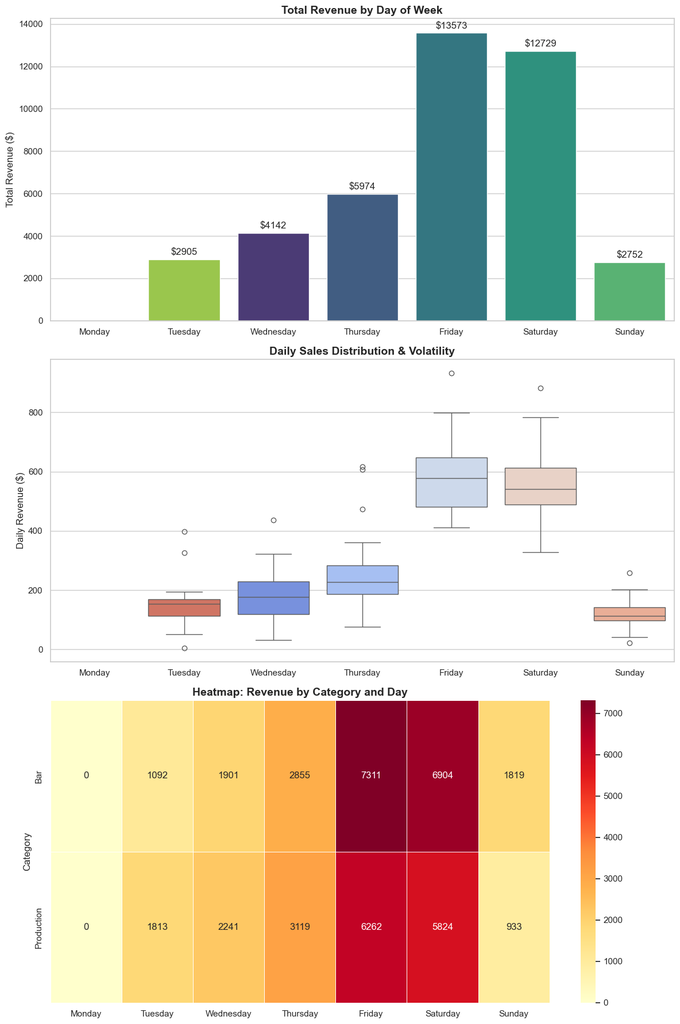

```python
# =============================================================================
# VISUALIZATION: WEEKLY ANALYSIS (CORRECTED)
# =============================================================================
import matplotlib.pyplot as plt
import seaborn as sns
import os

# Style configuration
sns.set(style="whitegrid")

# 1. Define Translation Mapping (Spanish to English)
day_translation = {
    'Lunes': 'Monday', 'Martes': 'Tuesday', 'Miércoles': 'Wednesday',
    'Jueves': 'Thursday', 'Viernes': 'Friday', 'Sábado': 'Saturday', 'Domingo': 'Sunday'
}

# 2. Define English Order for plotting
weekday_order = ['Monday', 'Tuesday', 'Wednesday', 'Thursday', 'Friday', 'Saturday', 'Sunday']

# 3. Prepare Data: Translate 'dia' to English for the plot
daily_sales = df_final.groupby(['fecha', 'dia'])['total'].sum().reset_index()
daily_sales['dia'] = daily_sales['dia'].map(day_translation)

# Create figure with subplots
fig, axes = plt.subplots(3, 1, figsize=(12, 18))

# PLOT 1: Total Revenue by Day of Week (Barplot)
sns.barplot(data=daily_sales, x='dia', y='total', order=weekday_order,
            estimator=sum, errorbar=None, palette='viridis',
            hue='dia', legend=False, ax=axes[0])

axes[0].set_title('Total Revenue by Day of Week', fontsize=14, fontweight='bold')
axes[0].set_ylabel('Total Revenue ($)')
axes[0].set_xlabel('')
# Add value labels
for container in axes[0].containers:
    axes[0].bar_label(container, fmt='$%.0f', padding=3)

# PLOT 2: Daily Sales Distribution (Boxplot)
sns.boxplot(data=daily_sales, x='dia', y='total', order=weekday_order,
            palette='coolwarm', hue='dia', legend=False, ax=axes[1])

axes[1].set_title('Daily Sales Distribution & Volatility', fontsize=14, fontweight='bold')
axes[1].set_ylabel('Daily Revenue ($)')
axes[1].set_xlabel('')

# PLOT 3: Heatmap (Day vs. Product Category)
# Pivot table using Spanish days first (to aggregate correctly), then translate columns
heatmap_data = df_final.pivot_table(index='tipo_producto', columns='dia', values='total', aggfunc='sum').fillna(0)
heatmap_data = heatmap_data.rename(columns=day_translation) # Translate columns to English

# Reindex to ensure all days appear in order
heatmap_data = heatmap_data.reindex(columns=weekday_order, fill_value=0)

sns.heatmap(heatmap_data, annot=True, fmt='.0f', cmap='YlOrRd', linewidths=.5, ax=axes[2])
axes[2].set_title('Heatmap: Revenue by Category and Day', fontsize=14, fontweight='bold')
axes[2].set_xlabel('')
axes[2].set_ylabel('Category')

plt.tight_layout()

# --- SAVE FIGURE ---
if not os.path.exists('doc'):
    os.makedirs('doc')
save_path = os.path.join('doc', 'weekly_analysis_summary.png')
plt.savefig(save_path, dpi=300, bbox_inches='tight')
print(f"Plot saved to {save_path}")

plt.show()
```

### 2️⃣ PEAK & OFF-PEAK HOURS (CRITICAL - Shift Management & Efficiency)

**Key Questions:**

- What are the 3-4 hours with the highest transaction volume?
- At what time is it most profitable to have more staff?
- Are there hours with zero revenue (dead hours)?

**Recommended Analysis:**

```python
# --- ANALYSIS 2: PEAK & OFF-PEAK HOURS ---
print("="*80)
print("ANALYSIS 2: PEAK & OFF-PEAK HOURS (Shift Management)")
print("="*80)

hourly_stats = df_final.groupby('hour').agg({
    'id': 'count',
    'total': ['sum', 'mean'],
    'cantidad': 'sum',
    'mesero': 'nunique'
}).round(2)

hourly_stats.columns = ['order_count', 'revenue', 'avg_ticket', 'quantity', 'active_staff']
hourly_stats['revenue_per_staff'] = (hourly_stats['revenue'] / hourly_stats['active_staff']).round(2)
hourly_stats['revenue_per_order'] = (hourly_stats['revenue'] / hourly_stats['order_count']).round(2)

# Hour Classification
hourly_stats['classification'] = pd.cut(hourly_stats['revenue'],
                                      bins=[0, hourly_stats['revenue'].quantile(0.33),
                                          hourly_stats['revenue'].quantile(0.67),
                                          hourly_stats['revenue'].max()],
                                      labels=['Off-Peak', 'Standard', 'Peak'],
                                      include_lowest=True)

print("\nHOURLY STATISTICS:")
print(hourly_stats.to_string())

# Top 5 Peak and Off-Peak hours
print("\n\nTOP 5 PEAK HOURS (by Revenue):")
top_hours = hourly_stats.nlargest(5, 'revenue')
for idx, (hour, row) in enumerate(top_hours.iterrows(), 1):
    print(f"  {idx}. {hour:02d}:00 - ${row['revenue']:>8,.2f} | {int(row['order_count'])} orders | Avg Ticket: ${row['avg_ticket']:.2f}")

print("\n\nTOP 5 OFF-PEAK HOURS (by Revenue):")
low_hours = hourly_stats.nsmallest(5, 'revenue')
for idx, (hour, row) in enumerate(low_hours.iterrows(), 1):
    print(f"  {idx}. {hour:02d}:00 - ${row['revenue']:>8,.2f} | {int(row['order_count'])} orders | Avg Ticket: ${row['avg_ticket']:.2f}")

# Staffing Recommendation
print("\n\nSTAFFING SHIFT RECOMMENDATION:")
print("  • Afternoon (14:00-17:00):  Reduced Staff (1-2)")
print("  • Evening (17:00-22:00):  Standard Staff (3-4)")
print("  • Night (22:00-02:00):    Full Staff (4-5)")
print("  • Early Morning (02:00-14:00): Skeleton Crew (1)")

print("\n" + "="*80)
```

```
================================================================================
ANALYSIS 2: PEAK & OFF-PEAK HOURS (Shift Management)
================================================================================

HOURLY STATISTICS:
      order_count  revenue  avg_ticket  quantity  active_staff  revenue_per_staff  revenue_per_order classification
hour
0             720  3045.50        4.23       999             7             435.07               4.23       Standard
1             598  2314.60        3.87       847             7             330.66               3.87       Standard
2             130   606.30        4.66       225             5             121.26               4.66       Off-Peak
3               3    16.00        5.33         4             1              16.00               5.33       Off-Peak
4               1     7.50        7.50         1             1               7.50               7.50       Off-Peak
14              5    38.75        7.75         9             2              19.38               7.75       Off-Peak
15            151   812.15        5.38       200             3             270.72               5.38       Off-Peak
16            340  1775.05        5.22       432             5             355.01               5.22       Standard
17            518  2389.10        4.61       651             7             341.30               4.61       Standard
18            682  3299.10        4.84       876             6             549.85               4.84       Standard
19            847  4254.05        5.02      1018             6             709.01               5.02           Peak
20           1072  5568.90        5.19      1332             8             696.11               5.19           Peak
21           1335  6790.85        5.09      1708             8             848.86               5.09           Peak
22           1328  6129.50        4.62      1722             8             766.19               4.62           Peak
23           1091  5027.85        4.61      1506             8             628.48               4.61           Peak


TOP 5 PEAK HOURS (by Revenue):
  1. 21:00 - $6,790.85 | 1335 orders | Avg Ticket: $5.09
  2. 22:00 - $6,129.50 | 1328 orders | Avg Ticket: $4.62
  3. 20:00 - $5,568.90 | 1072 orders | Avg Ticket: $5.19
  4. 23:00 - $5,027.85 | 1091 orders | Avg Ticket: $4.61
  5. 19:00 - $4,254.05 | 847 orders | Avg Ticket: $5.02


TOP 5 OFF-PEAK HOURS (by Revenue):
  1. 04:00 - $    7.50 | 1 orders | Avg Ticket: $7.50
  2. 03:00 - $   16.00 | 3 orders | Avg Ticket: $5.33
  3. 14:00 - $   38.75 | 5 orders | Avg Ticket: $7.75
  4. 02:00 - $  606.30 | 130 orders | Avg Ticket: $4.66
  5. 15:00 - $  812.15 | 151 orders | Avg Ticket: $5.38


STAFFING SHIFT RECOMMENDATION:
  • Afternoon (14:00-17:00):  Reduced Staff (1-2)
  • Evening (17:00-22:00):  Standard Staff (3-4)
  • Night (22:00-02:00):    Full Staff (4-5)
  • Early Morning (02:00-14:00): Skeleton Crew (1)

================================================================================
```

```
Plot saved to doc\hourly_demand_summary.png
```

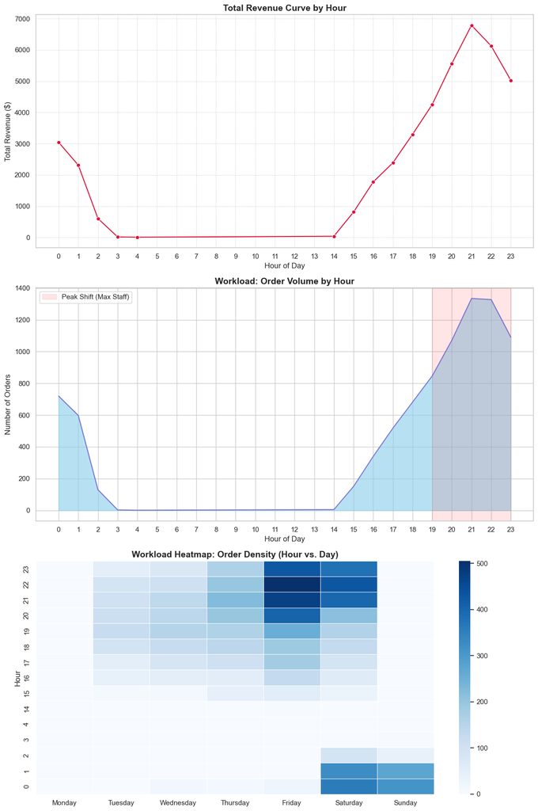

```python
# =============================================================================
# VISUALIZATION: HOURLY DEMAND AND SHIFT MANAGEMENT (CORRECTED)
# =============================================================================
import matplotlib.pyplot as plt
import seaborn as sns
import os

# 1. Setup Translations and Order
day_translation = {
    'Lunes': 'Monday', 'Martes': 'Tuesday', 'Miércoles': 'Wednesday',
    'Jueves': 'Thursday', 'Viernes': 'Friday', 'Sábado': 'Saturday', 'Domingo': 'Sunday'
}
weekday_order = ['Monday', 'Tuesday', 'Wednesday', 'Thursday', 'Friday', 'Saturday', 'Sunday']

fig, axes = plt.subplots(3, 1, figsize=(12, 18))

# PLOT 1: Total Revenue Curve by Hour (Lineplot)
sns.lineplot(data=df_final, x='hour', y='total', estimator='sum', errorbar=None, marker='o', color='crimson', ax=axes[0])
axes[0].set_title('Total Revenue Curve by Hour', fontsize=14, fontweight='bold')
axes[0].set_ylabel('Total Revenue ($)')
axes[0].set_xlabel('Hour of Day')
axes[0].set_xticks(range(0, 24))
axes[0].grid(True, which='both', linestyle='--', linewidth=0.5)

# PLOT 2: Order Volume (Area)
orders_per_hour = df_final.groupby('hour')['id'].count()
axes[1].fill_between(orders_per_hour.index, orders_per_hour.values, color='skyblue', alpha=0.6)
axes[1].plot(orders_per_hour.index, orders_per_hour.values, color='slateblue', alpha=0.8)
axes[1].set_title('Workload: Order Volume by Hour', fontsize=14, fontweight='bold')
axes[1].set_ylabel('Number of Orders')
axes[1].set_xlabel('Hour of Day')
axes[1].set_xticks(range(0, 24))

# Add staffing zones visual suggestion
axes[1].axvspan(19, 23, color='red', alpha=0.1, label='Peak Shift (Max Staff)')
axes[1].legend()

# PLOT 3: Heatmap (Hour vs. Day) - FIX APPLIED HERE
# Group by Spanish day names first
pivot_hours = df_final.groupby(['dia', 'hour'])['id'].count().reset_index()

# Translate day names to English BEFORE pivoting
pivot_hours['dia'] = pivot_hours['dia'].map(day_translation)

# Create Pivot Table
pivot_hours = pivot_hours.pivot(index='hour', columns='dia', values='id').fillna(0)

# Reindex to ensure correct English order (Monday -> Sunday)
pivot_hours = pivot_hours.reindex(columns=weekday_order, fill_value=0)

sns.heatmap(pivot_hours, cmap='Blues', annot=False, linewidths=.5, ax=axes[2])
axes[2].set_title('Workload Heatmap: Order Density (Hour vs. Day)', fontsize=14, fontweight='bold')
axes[2].set_ylabel('Hour')
axes[2].set_xlabel('')
axes[2].invert_yaxis() # 00:00 at the bottom

plt.tight_layout()

# --- SAVE FIGURE ---
if not os.path.exists('doc'):
    os.makedirs('doc')
save_path = os.path.join('doc', 'hourly_demand_summary.png')
plt.savefig(save_path, dpi=300, bbox_inches='tight')
print(f"Plot saved to {save_path}")

plt.show()
```

### 3️⃣ HOLIDAY IMPACT ANALYSIS (Consumption Patterns)

**Key Questions:**

- Do holidays increase or decrease sales?
- Is there a "pre-holiday" effect (day before)?
- Is there a "post-holiday" effect (1-2 days after)?
- What is the most significant holiday pattern?

**Recommended Analysis:**

```
BENCHMARK COMPARISON: Holiday vs. Standard Weekday Average:
```

|  | Date | Event | Holiday_Sales | Normal_Avg_Sales | Difference ($) | Variation (%) |
| --- | --- | --- | --- | --- | --- | --- |
| 0 | 2025-08-10 | Holiday (Domingo) | 112.85 | 121.242857 | -8.392857 | -6.922352 |
| 1 | 2025-10-09 | Holiday (Jueves) | 474.20 | 249.984091 | 224.215909 | 89.692071 |
| 2 | 2025-10-10 | Holiday (Viernes) | 475.95 | 595.343182 | -119.393182 | -20.054514 |
| 3 | 2025-11-02 | Holiday (Domingo) | 93.25 | 121.242857 | -27.992857 | -23.088253 |

```
Plot saved to doc\holiday_impact_analysis.png
```

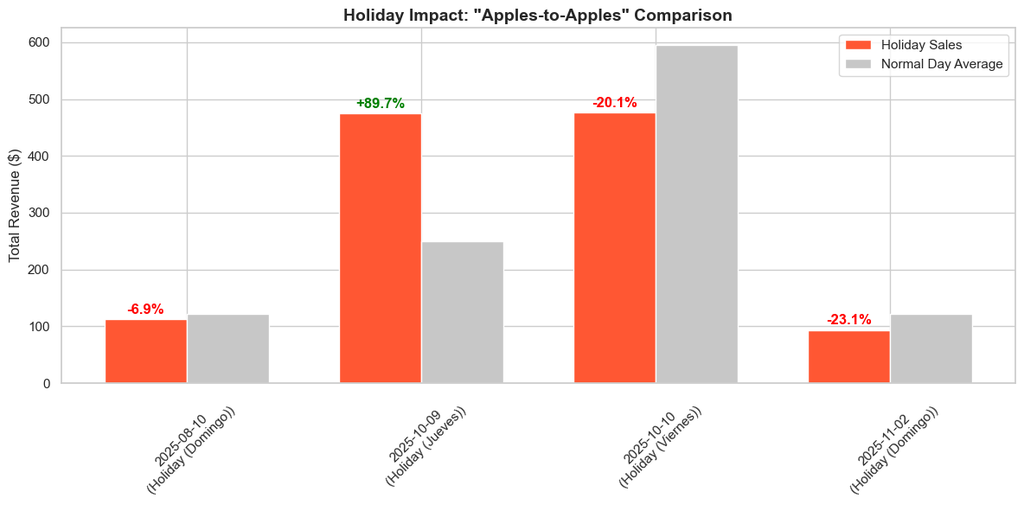

```python
# =============================================================================
# ANALYSIS 3: HOLIDAY IMPACT (Benchmark Comparison)
# =============================================================================
import os # Added for path joining

# 1. Calculate total daily sales
daily_sales = df_final.groupby(['fecha', 'dia', 'es_festivo'])['total'].sum().reset_index()

# 2. Separate normal days and calculate average sales per weekday
normal_days = daily_sales[daily_sales['es_festivo'] == 0]
normal_day_benchmark = normal_days.groupby('dia')['total'].mean().to_dict()

# 3. Analyze each specific holiday
holiday_analysis = []
actual_holidays = daily_sales[daily_sales['es_festivo'] == 1].copy()

for idx, row in actual_holidays.iterrows():
    date = row['fecha'].strftime('%Y-%m-%d')
    weekday = row['dia']
    holiday_sales = row['total']

    # Get the benchmark average for that specific weekday
    normal_avg = normal_day_benchmark.get(weekday, 0)

    diff_currency = holiday_sales - normal_avg
    diff_percent = ((holiday_sales / normal_avg) - 1) * 100 if normal_avg > 0 else 0

    holiday_analysis.append({
        'Date': date,
        'Event': f"Holiday ({weekday})",
        'Holiday_Sales': holiday_sales,
        'Normal_Avg_Sales': normal_avg,
        'Difference ($)': diff_currency,
        'Variation (%)': diff_percent
    })

# Create analysis DataFrame
df_holiday_impact = pd.DataFrame(holiday_analysis)

# Display table
print("BENCHMARK COMPARISON: Holiday vs. Standard Weekday Average:")
display(df_holiday_impact)

# =============================================================================
# COMPARATIVE PLOT
# =============================================================================
if not df_holiday_impact.empty:
    fig, ax = plt.subplots(figsize=(12, 6))

    x = range(len(df_holiday_impact))
    width = 0.35

    # Holiday Sales Bars
    ax.bar([i - width/2 for i in x], df_holiday_impact['Holiday_Sales'], width, label='Holiday Sales', color='#FF5733')

    # Normal Average Bars
    ax.bar([i + width/2 for i in x], df_holiday_impact['Normal_Avg_Sales'], width, label='Normal Day Average', color='#C7C7C7')

    ax.set_ylabel('Total Revenue ($)')
    ax.set_title('Holiday Impact: "Apples-to-Apples" Comparison', fontsize=14, fontweight='bold')
    ax.set_xticks(x)
    ax.set_xticklabels(df_holiday_impact['Date'] + '\n(' + df_holiday_impact['Event'] + ')', rotation=45)
    ax.legend()

    # Add percentage labels
    for i, row in df_holiday_impact.iterrows():
        color = 'green' if row['Variation (%)'] > 0 else 'red'
        symbol = '+' if row['Variation (%)'] > 0 else ''
        ax.text(i - width/2, row['Holiday_Sales'] + 5, f"{symbol}{row['Variation (%)']:.1f}%",
                ha='center', va='bottom', color=color, fontweight='bold')

    plt.tight_layout()

    # --- SAVE FIGURE ---
    if not os.path.exists('doc'):
        os.makedirs('doc')
    save_path = os.path.join('doc', 'holiday_impact_analysis.png')
    plt.savefig(save_path, dpi=300, bbox_inches='tight')
    print(f"Plot saved to {save_path}")

    plt.show()
else:
    print("No holiday data found to plot in the filtered dataset.")
```

### 4️⃣ SOCCER MATCH IMPACT (Behavioral Factor)

**Key Questions:**

- Do national team matches increase or decrease sales?
- Is there a variation by beverage type (e.g., more beer)?

**Recommended Analysis:**

```
IMPACT OF NATIONAL TEAM ('La Tri') MATCHES:
```

|  | Date | Day | Match_Day_Sales | Expected_Sales | Impact (%) |
| --- | --- | --- | --- | --- | --- |
| 0 | 2025-06-05 | Jueves | 615.75 | 226.254762 | 172.148968 |
| 1 | 2025-06-10 | Martes | 325.75 | 124.912500 | 160.782548 |
| 2 | 2025-09-04 | Jueves | 606.75 | 226.254762 | 168.171151 |
| 3 | 2025-09-09 | Martes | 397.50 | 124.912500 | 218.222756 |
| 4 | 2025-10-10 | Viernes | 475.95 | 595.343182 | -20.054514 |
| 5 | 2025-10-14 | Martes | 182.90 | 124.912500 | 46.422496 |

```
Plot saved to doc\soccer_match_impact.png
```

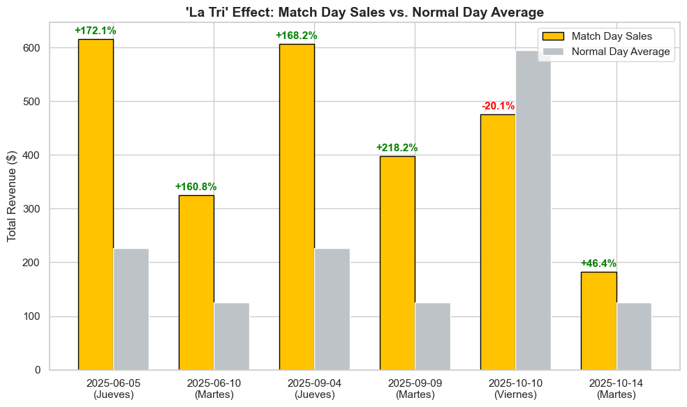

```python
# =============================================================================
# ANALYSIS 4: SOCCER MATCH IMPACT (Benchmark Comparison)
# =============================================================================
import os # Added for path joining

# 1. Group sales by date and match status
daily_sales_soccer = df_final.groupby(['fecha', 'dia', 'es_partido_ecuador'])['total'].sum().reset_index()

# 2. Calculate Benchmark (days WITHOUT a match)
days_no_match = daily_sales_soccer[daily_sales_soccer['es_partido_ecuador'] == 0]
benchmark_no_match = days_no_match.groupby('dia')['total'].mean().to_dict()

# 3. Analyze each match day
match_analysis = []
actual_match_days = daily_sales_soccer[daily_sales_soccer['es_partido_ecuador'] == 1].copy()

if not actual_match_days.empty:
    for idx, row in actual_match_days.iterrows():
        date = row['fecha'].strftime('%Y-%m-%d')
        weekday = row['dia']
        actual_sales = row['total']

        # Compare against the average for that specific weekday
        expected_sales = benchmark_no_match.get(weekday, 0)

        variation = ((actual_sales / expected_sales) - 1) * 100 if expected_sales > 0 else 0

        match_analysis.append({
            'Date': date,
            'Day': weekday,
            'Match_Day_Sales': actual_sales,
            'Expected_Sales': expected_sales,
            'Impact (%)': variation
        })

    df_match_impact = pd.DataFrame(match_analysis)

    # Display table
    print("IMPACT OF NATIONAL TEAM ('La Tri') MATCHES:")
    display(df_match_impact)

    # 4. COMPARATIVE BAR PLOT
    fig, ax = plt.subplots(figsize=(10, 6))

    x = range(len(df_match_impact))
    width = 0.35

    # Match Day Sales Bar (Ecuador Yellow)
    ax.bar([i - width/2 for i in x], df_match_impact['Match_Day_Sales'], width,
           label='Match Day Sales', color='#FFC300', edgecolor='black')

    # Normal Day Sales Bar (Gray)
    ax.bar([i + width/2 for i in x], df_match_impact['Expected_Sales'], width,
           label='Normal Day Average', color='#BDC3C7')

    ax.set_title("'La Tri' Effect: Match Day Sales vs. Normal Day Average", fontsize=14, fontweight='bold')
    ax.set_ylabel('Total Revenue ($)')
    ax.set_xticks(x)
    ax.set_xticklabels(df_match_impact['Date'] + '\n(' + df_match_impact['Day'] + ')')
    ax.legend()

    # Percentage Labels
    for i, row in df_match_impact.iterrows():
        v = row['Impact (%)']
        color_txt = 'green' if v > 0 else 'red'
        sign = '+' if v > 0 else ''
        ax.text(i - width/2, row['Match_Day_Sales'] + 5, f"{sign}{v:.1f}%",
                ha='center', va='bottom', color=color_txt, fontweight='bold', fontsize=11)

    plt.tight_layout()

    # --- SAVE FIGURE ---
    if not os.path.exists('doc'):
        os.makedirs('doc')
    save_path = os.path.join('doc', 'soccer_match_impact.png')
    plt.savefig(save_path, dpi=300, bbox_inches='tight')
    print(f"Plot saved to {save_path}")

    plt.show()

else:
    print("No soccer match dates found in the current data range.")
```

### 5️⃣ MARKET BASKET ANALYSIS (Combo & Upsell Strategy)

**Key Questions:**

- What products are frequently purchased together in the same order?
- Are there common combinations (e.g., Beer + Food)?
- Which combinations generate the most revenue?

**Recommended Analysis:**

```
Plot saved to doc\market_basket_heatmap.png
```

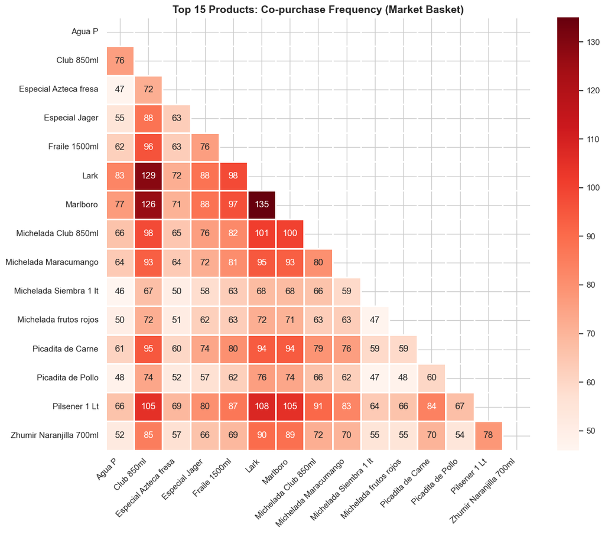

```python
# =============================================================================
# MARKET BASKET ANALYSIS: PRODUCT CO-OCCURRENCE
# =============================================================================
from itertools import combinations
from collections import Counter
import os # Ensure os is imported for saving

# 1. Prepare Co-occurrence Matrix (Top 15 products for readability)
top_n = 15
top_products_list = df_final['producto'].value_counts().head(top_n).index.tolist()

# Filter orders containing only top products
df_top = df_final[df_final['producto'].isin(top_products_list)]

# Generate Pairs
pairs = []
for order_id, group in df_top.groupby('id'):
    items = sorted(group['producto'].unique())
    if len(items) > 1:
        for pair in combinations(items, 2):
            pairs.append(pair)

# Count Frequencies
pair_counts = Counter(pairs)

# Create Matrix for Heatmap
unique_products = sorted(list(set([p for pair in pair_counts.keys() for p in pair])))
matrix = pd.DataFrame(0, index=unique_products, columns=unique_products)

for (prod1, prod2), count in pair_counts.items():
    matrix.loc[prod1, prod2] = count
    matrix.loc[prod2, prod1] = count # Symmetric matrix

# 2. HEATMAP VISUALIZATION
plt.figure(figsize=(12, 10))
mask = np.triu(np.ones_like(matrix, dtype=bool)) # Hide upper triangle to avoid duplication

sns.heatmap(matrix, annot=True, fmt='d', cmap='Reds', mask=mask, linewidths=1)
plt.title(f'Top {top_n} Products: Co-purchase Frequency (Market Basket)', fontsize=14, fontweight='bold')
plt.xticks(rotation=45, ha='right')
plt.tight_layout()

# --- SAVE FIGURE ---
if not os.path.exists('doc'):
    os.makedirs('doc')
save_path = os.path.join('doc', 'market_basket_heatmap.png')
plt.savefig(save_path, dpi=300, bbox_inches='tight')
print(f"Plot saved to {save_path}")

plt.show()
```

```
General Weather Plot saved to doc\weather_impact_general.png
```

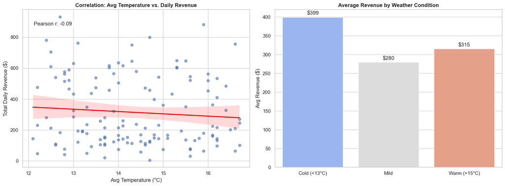

```
--- Generating Category Trend Plot ---
Analyzing trends for Top 4 Categories found: ['Cocktail', 'Tobacco', 'Bottles', 'Beer']
Category Weather Plot saved to doc\weather_impact_by_category.png
```

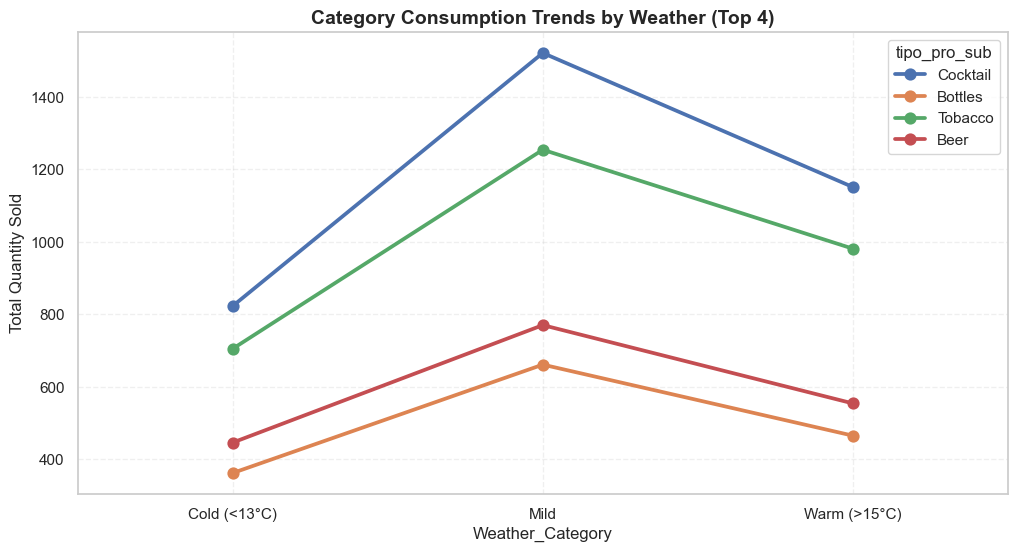

```python
# =============================================================================
# CLIMATIC ANALYSIS: TEMPERATURE vs. SALES (CORRECTED)
# =============================================================================
import matplotlib.pyplot as plt
import seaborn as sns
import os

# 1. Prepare Daily Data (Sum of sales & Mean Temp)
weather_sales = df_final.groupby('fecha').agg({
    'total': 'sum',
    'temp_promedio': 'mean',
    'id': 'count'
}).reset_index()

# Create Weather Categories (Binning)
weather_sales['Weather_Category'] = pd.cut(weather_sales['temp_promedio'],
                               bins=[0, 13, 15, 30],
                               labels=['Cold (<13°C)', 'Mild', 'Warm (>15°C)'])

# 2. GENERAL PLOTS (Scatter & Bar)
fig, axes = plt.subplots(1, 2, figsize=(16, 6))

# A) Scatter: Temp vs Total Revenue
sns.regplot(data=weather_sales, x='temp_promedio', y='total', scatter_kws={'alpha':0.6}, line_kws={'color':'red'}, ax=axes[0])
axes[0].set_title('Correlation: Avg Temperature vs. Daily Revenue', fontsize=12, fontweight='bold')
axes[0].set_xlabel('Avg Temperature (°C)')
axes[0].set_ylabel('Total Daily Revenue ($)')

# Calculate Correlation
corr = weather_sales['temp_promedio'].corr(weather_sales['total'])
axes[0].text(0.05, 0.9, f'Pearson r: {corr:.2f}', transform=axes[0].transAxes,
             bbox=dict(facecolor='white', alpha=0.8))

# B) Avg Sales by Weather Category
sns.barplot(data=weather_sales, x='Weather_Category', y='total', estimator='mean', errorbar=None, palette='coolwarm', ax=axes[1])
axes[1].set_title('Average Revenue by Weather Condition', fontsize=12, fontweight='bold')
axes[1].set_ylabel('Avg Revenue ($)')
axes[1].set_xlabel('')
for container in axes[1].containers:
    axes[1].bar_label(container, fmt='$%.0f', padding=3)

plt.tight_layout()

# --- SAVE FIGURE 1 ---
if not os.path.exists('doc'):
    os.makedirs('doc')
save_path1 = os.path.join('doc', 'weather_impact_general.png')
plt.savefig(save_path1, dpi=300, bbox_inches='tight')
print(f"General Weather Plot saved to {save_path1}")

plt.show()

# 3. SPECIFIC PRODUCT ANALYSIS (CORRECTED LOGIC)
print("\n--- Generating Category Trend Plot ---")

# AQUI ESTA LA CORRECCION:
# En lugar de adivinar los nombres, tomamos automáticamente el TOP 4 de subcategorías reales
top_categories = df_final['tipo_pro_sub'].value_counts().head(4).index.tolist()
print(f"Analyzing trends for Top 4 Categories found: {top_categories}")

# Filter data for these top categories
sales_cat_weather = df_final[df_final['tipo_pro_sub'].isin(top_categories)].copy()

# Merge with weather data
sales_cat_weather = sales_cat_weather.merge(weather_sales[['fecha', 'Weather_Category']], on='fecha', how='inner')

if not sales_cat_weather.empty:
    plt.figure(figsize=(12, 6))

    # Pointplot to show trends
    sns.pointplot(data=sales_cat_weather, x='Weather_Category', y='cantidad', hue='tipo_pro_sub',
                  estimator='sum', errorbar=None, markers='o')

    plt.title('Category Consumption Trends by Weather (Top 4)', fontsize=14, fontweight='bold')
    plt.ylabel('Total Quantity Sold')
    plt.grid(True, linestyle='--', alpha=0.3)

    # --- SAVE FIGURE 2 ---
    save_path2 = os.path.join('doc', 'weather_impact_by_category.png')
    plt.savefig(save_path2, dpi=300, bbox_inches='tight')
    print(f"Category Weather Plot saved to {save_path2}")

    plt.show()
else:
    print("⚠️ Error: No data available for the selected categories. Check your merge.")
```

```python
# =============================================================================
# PRICE ELASTICITY ANALYSIS: CALCULATION (FILTERED)
# =============================================================================
import pandas as pd
import numpy as np
from scipy.stats import pearsonr

# Manual Exclusion List (High rotation items / Standard fixed prices)
products_to_exclude = [
    'Pilsener 1 Lt',
    'Michelada Club 330ml',
    'Siembra 1lt',
    'Dorito',
    'Club 850ml'
]

# 1. Calculate Implicit Unit Price
df_final['unit_price'] = (df_final['total'] / df_final['cantidad']).round(2)

# 2. Filter products with price variation
product_list = df_final['producto'].unique()
elasticity_results = []

for prod in product_list:
    if prod in products_to_exclude:
        continue

    data_prod = df_final[df_final['producto'] == prod]

    # Check for >1 unique price and sufficient data points (>5 transactions)
    if data_prod['unit_price'].nunique() > 1 and len(data_prod) > 5:
        # Group by price to find avg demand at that price point
        demand_by_price = data_prod.groupby('unit_price')['cantidad'].mean().reset_index()

        # Pearson Correlation (Price vs. Quantity)
        if len(demand_by_price) > 1:
            corr, _ = pearsonr(demand_by_price['unit_price'], demand_by_price['cantidad'])

            if not np.isnan(corr):
                elasticity_results.append({
                    'Product': prod,
                    'Correlation': corr,
                    'Num_Prices': data_prod['unit_price'].nunique(),
                    'Total_Sales': data_prod['total'].sum()
                })

# 3. Create DataFrame and Sort
df_elasticity = pd.DataFrame(elasticity_results)

if not df_elasticity.empty:
    # Sort by Correlation Magnitude (Absolute value)
    df_elasticity['Abs_Corr'] = df_elasticity['Correlation'].abs()
    df_elasticity = df_elasticity.sort_values(by='Abs_Corr', ascending=False).drop(columns='Abs_Corr')

    print(f"Found {len(df_elasticity)} products with relevant price variations (excluding filtered items).")
    print("\nTOP 20 PRODUCTS WITH HIGHEST PRICE SENSITIVITY:")
    display(df_elasticity.head(20))
else:
    print("No products with sufficient price variation found after filtering.")
```

```
Found 12 products with relevant price variations (excluding filtered items).

TOP 20 PRODUCTS WITH HIGHEST PRICE SENSITIVITY:
```

|  | Product | Correlation | Num_Prices | Total_Sales |
| --- | --- | --- | --- | --- |
| 1 | RTD | -1.000000 | 2 | 40.00 |
| 2 | Canijo Tamarindo | -1.000000 | 2 | 606.00 |
| 6 | Switch Tamarindo | 1.000000 | 2 | 64.50 |
| 4 | Cubata Berrylicious | -1.000000 | 2 | 549.00 |
| 11 | Canelazo Amazonico | -1.000000 | 2 | 255.00 |
| 9 | Miraflores 750ml | -1.000000 | 2 | 102.25 |
| 7 | Cubata Guarana | 1.000000 | 2 | 247.50 |
| 8 | Zhumir Mango 700ml | 1.000000 | 2 | 770.00 |
| 3 | Fraile 1500ml | 0.994488 | 3 | 1783.50 |
| 0 | Zhumir Naranjilla 700ml | -0.971192 | 3 | 1152.50 |
| 10 | Zhumir Pink | 0.967868 | 3 | 370.50 |
| 5 | Haciendazo 1500ml | 0.866289 | 4 | 401.50 |

```
Plot saved to doc\price_elasticity_grid.png
```

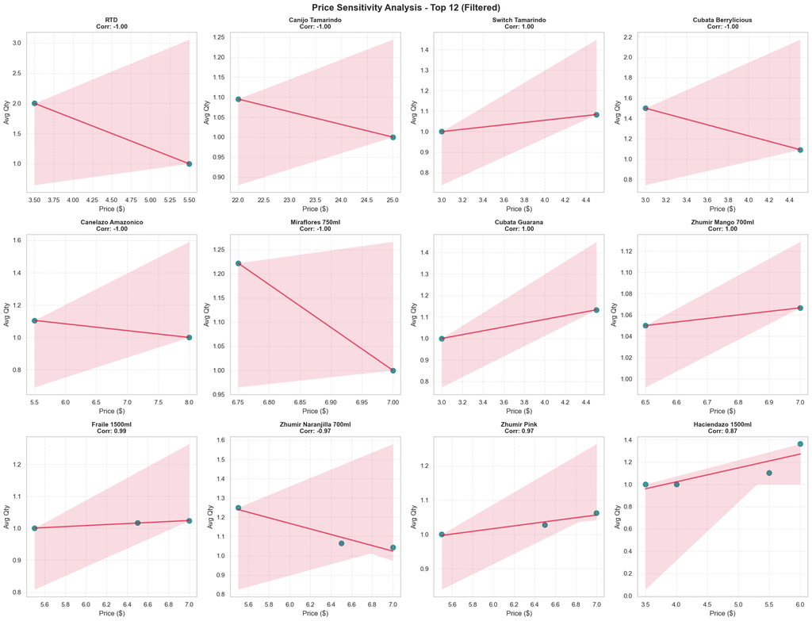

```python
# =============================================================================
# ELASTICITY VISUALIZATION (TOP 17 - FILTERED)
# =============================================================================
import math
import matplotlib.pyplot as plt
import seaborn as sns
import os

top_n_elasticity = 17

if not df_elasticity.empty:
    products_to_plot = df_elasticity.head(top_n_elasticity)['Product'].tolist()

    num_plots = len(products_to_plot)

    if num_plots > 0:
        cols = 4
        rows = math.ceil(num_plots / cols)

        # Dynamic Figure Size
        fig, axes = plt.subplots(rows, cols, figsize=(20, 5 * rows), sharey=False)
        axes = axes.flatten()

        for i, prod in enumerate(products_to_plot):
            data_prod = df_final[df_final['producto'] == prod]
            demand_price = data_prod.groupby('unit_price')['cantidad'].mean().reset_index()

            # Regression Plot
            sns.regplot(data=demand_price, x='unit_price', y='cantidad', ax=axes[i],
                        color='teal', scatter_kws={'s':80}, line_kws={'color':'crimson', 'alpha':0.7})

            # Get correlation value
            val_corr = df_elasticity[df_elasticity['Product'] == prod]['Correlation'].values
            corr_val = val_corr[0] if len(val_corr) > 0 else 0

            axes[i].set_title(f'{prod}\nCorr: {corr_val:.2f}', fontsize=11, fontweight='bold')
            axes[i].set_xlabel('Price ($)')
            axes[i].set_ylabel('Avg Qty')
            axes[i].grid(True, linestyle='--', alpha=0.4)

        # Hide empty axes
        for j in range(i + 1, len(axes)):
            axes[j].axis('off')

        plt.tight_layout()
        plt.suptitle(f"Price Sensitivity Analysis - Top {num_plots} (Filtered)", y=1.01, fontsize=16, fontweight='bold')

        # --- SAVE FIGURE ---
        if not os.path.exists('doc'):
            os.makedirs('doc')
        save_path = os.path.join('doc', 'price_elasticity_grid.png')
        plt.savefig(save_path, dpi=300, bbox_inches='tight')
        print(f"Plot saved to {save_path}")

        plt.show()
    else:
        print("No products to plot in selected top list.")
else:
    print("Insufficient data for visualization.")
```

## Price Elasticity Interpretation: Key Insights

This analysis details demand behavior in response to price fluctuations for the top 12 relevant products (excluding high-rotation staples). Products are segmented based on their correlation coefficient.

### 1. Price Sensitive Products (Economy Segment)

**Behavior:** Negative Correlation (~ -1.00). As unit price increases, average quantity sold decreases significantly. This indicates consumers of these specific products are highly cost-conscious.

- **Product List:** *3RTD, Canijo Tamarindo, Cubata Berrylicious, Canelazo Amazónico, Miraflores 750ml, Zhumir Naranjilla.*
- **Key Finding:** The **RTD** case is critical; demand doubles when the price drops to its historical minimum ($3.50) compared to its high point ($5.50).
- **Strategic Recommendation:** These items are ideal candidates for **Volume Drivers** (Happy Hours, 2-for-1 deals). Raising prices here carries a high risk of churn.

### 2. Inelastic Demand Products (Premium / Loyalty)

**Behavior:** Positive Correlation (~ 1.00). Surprisingly, sales for these products remain stable or even increase slightly at higher price points. This suggests strong brand loyalty or consumption during "Prime Time" (weekends/late night) where customers are less price-sensitive.

- **Product List:** *Fraile 1500ml, Zhumir Pink, Haciendazo 1500ml, Switch Tamarindo, Cubata Guaraná.*
- **Strategic Recommendation:** Opportunity to **maximize margins**. Maintaining standard prices or evaluating slight increases (5-10%) is recommended, as volume is not penalized by price. Aggressive discounting is unnecessary here.

*Methodological Note: Perfect correlations (1.00/-1.00) indicate historical oscillation between very few fixed price points (e.g., Regular Price vs. Offer Price).*

```
Plot saved to doc\customer_segmentation_clusters.png
```

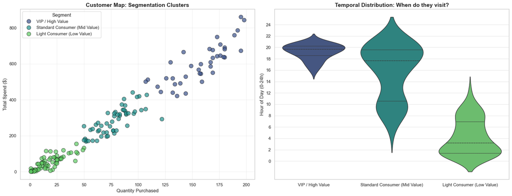

```
DETAILED SEGMENT PROFILE:
```

| Segment | Avg Ticket ($) | Avg Items | Peak Hour | Customer Count |
| --- | --- | --- | --- | --- |
| Light Consumer (Low Value) | 49.949275 | 17.405797 | 04:00 | 69 |
| Standard Consumer (Mid Value) | 281.324074 | 77.500000 | 15:00 | 54 |
| VIP / High Value | 600.953846 | 157.538462 | 19:00 | 39 |

```python
# =============================================================================
# ANALYSIS 4 IMPROVED: CUSTOMER SEGMENTATION + TIMING (K-MEANS)
# =============================================================================
from sklearn.cluster import KMeans
from sklearn.preprocessing import StandardScaler
import os

# 1. Create Ticket Profile
ticket_profile = df_final.groupby('id').agg({
    'total': 'sum',
    'cantidad': 'sum',
    'hour': 'mean'  # Avg hour of order
}).reset_index()

# 2. Clustering (K-Means)
scaler = StandardScaler()
# Use Total and Quantity for clustering (Hour is used for analysis only)
data_scaled = scaler.fit_transform(ticket_profile[['total', 'cantidad']])

kmeans = KMeans(n_clusters=3, random_state=42, n_init=10)
ticket_profile['Cluster'] = kmeans.fit_predict(data_scaled)

# 3. Rename Clusters (Automated Mapping)
cluster_means = ticket_profile.groupby('Cluster')['total'].mean().sort_values()
# English Labels
name_mapping = {
    cluster_means.index[0]: 'Light Consumer (Low Value)',
    cluster_means.index[1]: 'Standard Consumer (Mid Value)',
    cluster_means.index[2]: 'VIP / High Value'
}
ticket_profile['Segment'] = ticket_profile['Cluster'].map(name_mapping)

# ---------------------------------------------------------
# VISUALIZATION
# ---------------------------------------------------------
fig, axes = plt.subplots(1, 2, figsize=(18, 7))

# Plot A: Scatter (Spend vs Quantity)
sns.scatterplot(data=ticket_profile, x='cantidad', y='total', hue='Segment',
                palette='viridis', s=100, alpha=0.7, edgecolor='black', ax=axes[0])
axes[0].set_title('Customer Map: Segmentation Clusters', fontsize=14, fontweight='bold')
axes[0].set_xlabel('Quantity Purchased')
axes[0].set_ylabel('Total Spend ($)')
axes[0].legend(title='Segment')
axes[0].grid(True, alpha=0.3)

# Plot B: Violin Plot (Time vs Segment)
sns.violinplot(data=ticket_profile, x='Segment', y='hour', palette='viridis', ax=axes[1], inner="quartile")
axes[1].set_title('Temporal Distribution: When do they visit?', fontsize=14, fontweight='bold')
axes[1].set_ylabel('Hour of Day (0-24h)')
axes[1].set_xlabel('')
axes[1].set_yticks(range(0, 25, 2))
axes[1].grid(True, axis='y', alpha=0.5)

plt.tight_layout()

# --- SAVE FIGURE ---
if not os.path.exists('doc'):
    os.makedirs('doc')
save_path = os.path.join('doc', 'customer_segmentation_clusters.png')
plt.savefig(save_path, dpi=300, bbox_inches='tight')
print(f"Plot saved to {save_path}")

plt.show()

# Numerical Summary
print("DETAILED SEGMENT PROFILE:")
summary = ticket_profile.groupby('Segment').agg({
    'total': 'mean',
    'cantidad': 'mean',
    'hour': lambda x: f"{int(x.mean()):02d}:00",
    'id': 'count'
}).rename(columns={'total':'Avg Ticket ($)', 'cantidad':'Avg Items', 'hour':'Peak Hour', 'id':'Customer Count'})
display(summary)
```